# ECS530: (VIII) Spatial multilevel regression

Roger Bivand

Thursday 12 November 2020, 13:30-15.00

### Copyright

All the material presented here, to the extent it is original, is available under [CC-BY-SA](https://creativecommons.org/licenses/by-sa/4.0/). Parts build on joint tutorials with Edzer Pebesma.

### Required current contributed CRAN packages:

I am running R 4.0.3, with recent `update.packages()`.

```r
needed <- c("coda", "INLABMA", "INLA", "ggplot2", "R2BayesX", "colorspace", "BayesXsrc", "HSAR", "hglm", "MatrixModels", "lme4", "spdep", "sp", "tmap", "spData", "sf")
```

### Script

Script and data at https://github.com/rsbivand/ECS530_h20/raw/main/ECS530_VIII.zip. Download to suitable location, unzip and use as basis.

## Schedule

- 9/11 (I) Spatial data representation, (II) Support+topology, input/output
- 10/11 (III) Coordinate reference systems, (IV) Visualization
- 11/11 (VI) Spatial autocorrelation, *project surgery*
- 12/11 (VII) Spatial regression, **(preVIII) Spatial econometrics**, **(VIII) Spatial multilevel regression**
- 13/11 (IX) Interpolation, point processes, *project surgery*, *presentation*
- 14/11 *Presentations*

## Session VIII

- 13:30-14:00 Introduction, Boston data set (II)
- 14:0-14:30 Multilevel Boston
- 14:30-15:00 Bayesian spatial econometrics

# Multilevel Boston

### Reading the shapefile

```r
library(sf)
library(spData)
b506 <- st_read(system.file("shapes/boston_tracts.shp", package="spData")[1])
```

### Aggregating geometries to model output zones

After dropping the censored census tracts, we need to derive the model output zones. The aggregate method calls `sf::st_union` on each unique grouping value, but the function called internally is a trick, putting only the first value of each variable in the output; for this reason we only retain the ids:

```r
b489 <- b506[b506$censored == "no",]
t0 <- aggregate(b489, list(ids = b489$NOX_ID), head, n = 1)
b94 <- t0[, c("ids", attr(t0, "sf_column"))]
```

### Finding model output zones neighbours

We can find contiguous neighbours using `sf::st_relate`, but this does not yet scale to large numbers of geometries; we also find a no-neighbour model output zone:

```r
st_queen <- function(a, b = a) st_relate(a, b, pattern = "F***T****")
qm1 <- st_queen(b94)
```

```
## although coordinates are longitude/latitude, st_relate_pattern assumes that they are planar
```

```r
any(sapply(qm1, length) == 0)
```

```
## [1] TRUE
```

### Problem of no-neighbour zone

Both Bayesian multilevel spatial model fitting approaches fail on the no-neighbour case (the spatially structured random effect cannot be estimated), so we need to drop those census tracts and re-aggregate to model output zones with neighbours:

```r
NOX_ID_no_neighs <- b94$ids[which(sapply(qm1, length) == 0)]
b487 <- b489[is.na(match(b489$NOX_ID, NOX_ID_no_neighs)),]
t0 <- aggregate(b487, list(ids = b487$NOX_ID), head, n = 1)
b93 <- t0[, c("ids", attr(t0, "sf_column"))]
```

and finally create the same kind of `nb` object as used in **spdep**:

```r
qm_93 <- st_queen(b93)
```

```
## although coordinates are longitude/latitude, st_relate_pattern assumes that they are planar
```

```r
class(qm_93) <- "nb"
attr(qm_93, "region.id") <- as.character(b93$ids)
```

### NOX values (parts per 10 million)

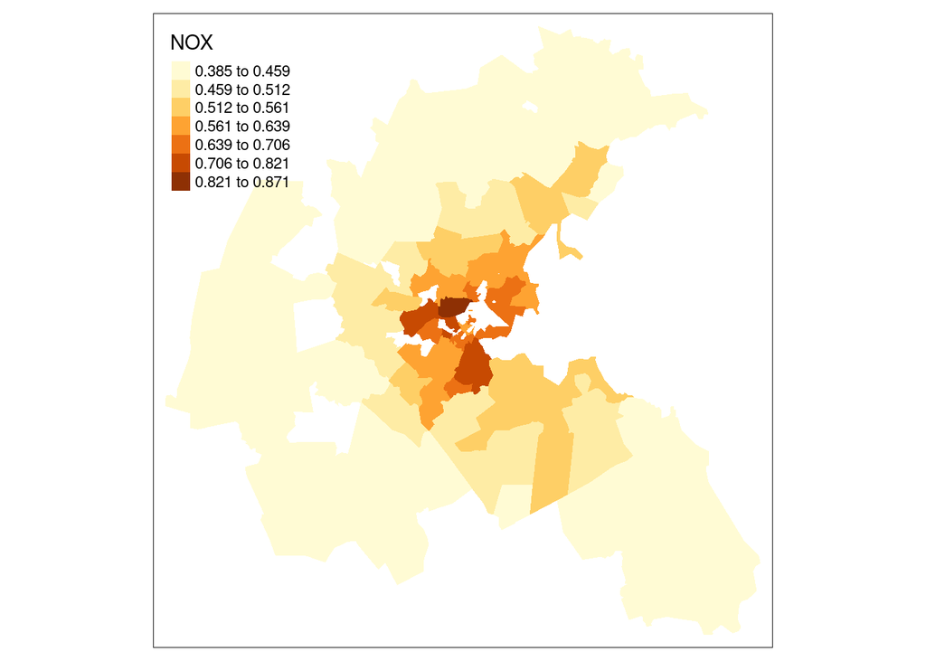

```r
library(tmap)
tm_shape(b487) + tm_fill("NOX", n=7, style="fisher")
```

## Multilevel spatial models

The ZN, INDUS, NOX, RAD, TAX and PTRATIO variables show effectively no variability within the TASSIM zones, so in a multilevel model the random effect may absorb their influence. The model as a whole, before introducing random effects, is:

```r
form <- formula(log(median) ~ CRIM + ZN + INDUS + CHAS + I((NOX*10)^2) + I(RM^2) +
  AGE + log(DIS) + log(RAD) + TAX + PTRATIO + I(BB/100) + log(I(LSTAT/100)))
```

### Empirical approach

We will be using row-standardised contiguity neighbours derived from the map of census tracts, and from the map of merged census tracts constituting approximate TASSIM zones

```r
q487 <- st_queen(sf::st_make_valid(b487))
q487[which(sapply(q487, length) == 0)] <- 0L
class(q487) <- "nb"
suppressPackageStartupMessages(library(spdep))
lw487 <- nb2listw(q487, zero.policy=TRUE)
```

### Model comparisons

This is not completed as a proper set of comparisons with this data set - (Bivand et al. 2017; Bivand 2017) contains comparisons for Beijing land parcels and a housing data set for SW Norway. The baseline tract level residual spatial autocorrelation is measured using a proper Moran test (b487 is an `sf` object):

```r
OLS <- lm(form, data=b487)
lm.morantest(OLS, lw487, alternative="two.sided", zero.policy=TRUE)
```

```
##
##  Global Moran I for regression residuals
##
## data:
## model: lm(formula = form, data = b487)
## weights: lw487
##
## Moran I statistic standard deviate = 15.898, p-value < 2.2e-16
## alternative hypothesis: two.sided
## sample estimates:
## Observed Moran I      Expectation         Variance
##     0.4165620055    -0.0168821367     0.0007433579
```

### Linear Mixed Effects

Here we fit air pollution model output zone unstructured random effects using **lme4**, and the residual spatial autocorrelation falls (indicative not proper test):

```r
library(lme4)
MLM <- lmer(update(form, . ~ . + (1 | NOX_ID)), data=b487, REML=FALSE)
moran.test(residuals(MLM), lw487, alternative="two.sided", zero.policy=TRUE)
```

```
##
##  Moran I test under randomisation
##
## data:  residuals(MLM)
## weights: lw487  n reduced by no-neighbour observations
##
##
## Moran I statistic standard deviate = 2.0662, p-value = 0.03881
## alternative hypothesis: two.sided
## sample estimates:
## Moran I statistic       Expectation          Variance
##      0.0555611072     -0.0020618557      0.0007777858
```

```r
b93$MLM_re <- ranef(MLM)[[1]][,1]
```

### Data setup

Both **hglm** and **HSAR** need sparse design matrices precomputed:

```r
library(Matrix)
suppressMessages(library(MatrixModels))
Delta <- as(model.Matrix(~ -1 + as.factor(NOX_ID), data=b487, sparse=TRUE), "dgCMatrix")
M <- as(nb2listw(qm_93, style="B"), "CsparseMatrix")
```

### Using HGLM

Fitting the air pollution model output zone unstructured random effects using hierarchical GLM also works (indicative test):

```r
library(hglm)
y_hglm <- log(b487$median)
X_hglm <- model.matrix(OLS)
suppressWarnings(HGLM_iid <- hglm(y=y_hglm, X=X_hglm, Z=Delta))
moran.test(HGLM_iid$resid, lw487, alternative="two.sided", zero.policy=TRUE)
```

```
##
##  Moran I test under randomisation
##
## data:  HGLM_iid$resid
## weights: lw487  n reduced by no-neighbour observations
##
##
## Moran I statistic standard deviate = 1.9175, p-value = 0.05518
## alternative hypothesis: two.sided
## sample estimates:
## Moran I statistic       Expectation          Variance
##      0.0514037549     -0.0020618557      0.0007774949
```

As does a Simultaneous Autoregressive (SAR) fitted with **hglm**, modelling with air pollution model output zone spatially structured random effects:

```r
HGLM_sar <- hglm(y=y_hglm, X=X_hglm, Z=Delta, rand.family=SAR(D=M))
moran.test(HGLM_sar$resid, lw487, alternative="two.sided", zero.policy=TRUE)
```

```
##
##  Moran I test under randomisation
##
## data:  HGLM_sar$resid
## weights: lw487  n reduced by no-neighbour observations
##
##
## Moran I statistic standard deviate = 1.7161, p-value = 0.08614
## alternative hypothesis: two.sided
## sample estimates:
## Moran I statistic       Expectation          Variance
##      0.0457782452     -0.0020618557      0.0007771106
```

```r
b93$HGLM_re <- unname(HGLM_iid$ranef)
b93$HGLM_ss <- HGLM_sar$ranef[,1]
```

## Unstructured random effects: TASSIM zones

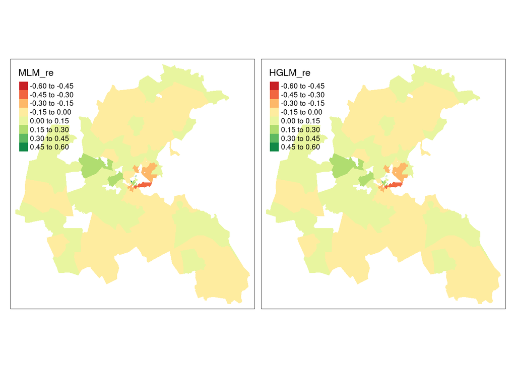

```r
brks <- seq(-0.6, 0.6, 0.15)
tm_shape(b93) + tm_fill(c("MLM_re", "HGLM_re"), breaks=brks, midpoint=0)
```

### Using HSAR

**HSAR** fits the model with air pollution model output zone spatially structured random effects using MCMC:

```r
library(HSAR)
HSAR <- hsar(form, data=b487, W=NULL, M=M, Delta=Delta,
             burnin=500, Nsim=5000, thinning=1)
```

```r
b93$HSAR_ss <- HSAR$Mus[1,]
```

### Spatially structured random effects: TASSIM zones

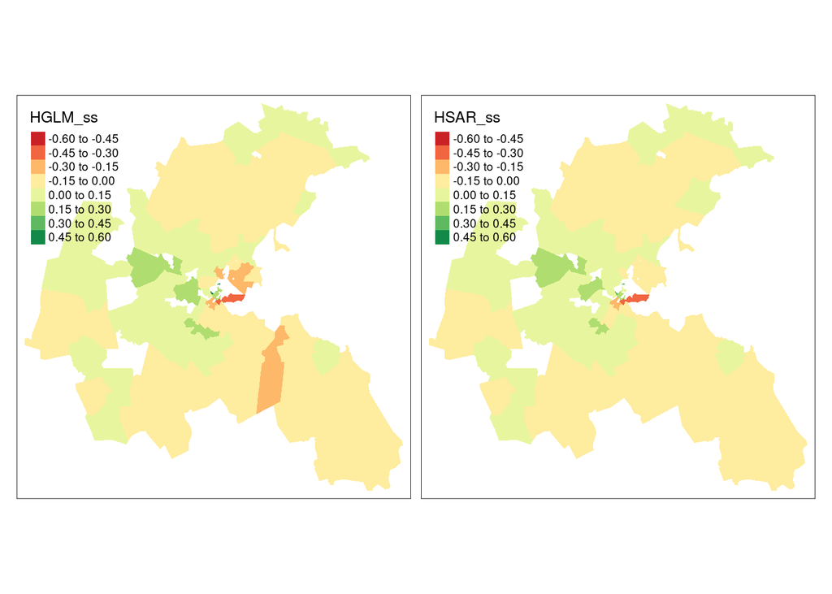

```r
tm_shape(b93) + tm_fill(c("HGLM_ss", "HSAR_ss"), breaks=brks, midpoint=0)
```

### Using R2BayesX

We can use **R2BayesX** for the same purposes, for both unstructured and spatially structured random effects by MCMC:

```r
suppressPackageStartupMessages(library(R2BayesX))
BX_iid <- bayesx(update(form, . ~ . - CHAS + sx(NOX_ID, bs="re")), family="gaussian", data=b487, method="MCMC", iterations=12000, burnin=2000, step=2, seed=123)
moran.test(residuals(BX_iid), lw487, alternative="two.sided", zero.policy=TRUE)
```

```
##
##  Moran I test under randomisation
##
## data:  residuals(BX_iid)
## weights: lw487  n reduced by no-neighbour observations
##
##
## Moran I statistic standard deviate = 1.9018, p-value = 0.05719
## alternative hypothesis: two.sided
## sample estimates:
## Moran I statistic       Expectation          Variance
##      0.0509772955     -0.0020618557      0.0007777562
```

```r
b93$BX_re <- BX_iid$effects["sx(NOX_ID):re"][[1]]$Mean
```

The spatially structured random effects are modelled as an intrinsic Conditional Autoregressive (CAR), not a SAR with a parameter, but turn out very similar:

```r
RBX_gra <- nb2gra(qm_93)
BX_mrf <- bayesx(update(form, . ~ . - CHAS + sx(NOX_ID, bs="mrf", map=RBX_gra)),
family="gaussian", data=b487, method="MCMC", iterations=12000, burnin=2000,
step=2, seed=123)
moran.test(residuals(BX_mrf), lw487, alternative="two.sided", zero.policy=TRUE)
```

```
##
##  Moran I test under randomisation
##
## data:  residuals(BX_mrf)
## weights: lw487  n reduced by no-neighbour observations
##
##
## Moran I statistic standard deviate = 1.7881, p-value = 0.07376
## alternative hypothesis: two.sided
## sample estimates:
## Moran I statistic       Expectation          Variance
##       0.047795064      -0.002061856       0.000777443
```

```r
b93$BX_ss <- BX_mrf$effects["sx(NOX_ID):mrf"][[1]]$Mean
```

## BayesX separate model random effects

```r
tm_shape(b93) +  tm_fill(c("BX_re", "BX_ss"), breaks=brks)
```

```
## Variable(s) "BX_re" contains positive and negative values, so midpoint is set to 0. Set midpoint = NA to show the full spectrum of the color palette.
```

```
## Variable(s) "BX_ss" contains positive and negative values, so midpoint is set to 0. Set midpoint = NA to show the full spectrum of the color palette.
```

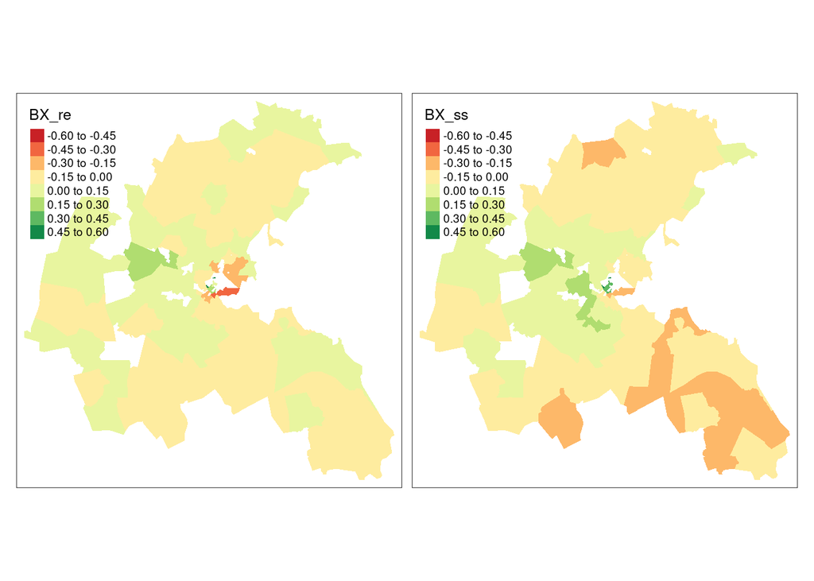

### BYM with BayesX

Combining the CAR and unstructured random effects in one model is the Besag, York, Mollie (BYM) model:

```r
b487$d_id <- as.integer(as.factor(b487$NOX_ID))
BX_bym <- bayesx(update(form, . ~ . - CHAS + sx(NOX_ID, bs="mrf", map=RBX_gra) +
sx(d_id, bs="re")), family="gaussian", data=b487, method="MCMC",
iterations=12000, burnin=2000, step=2, seed=123)
moran.test(residuals(BX_bym), lw487, alternative="two.sided", zero.policy=TRUE)
```

```
##
##  Moran I test under randomisation
##
## data:  residuals(BX_bym)
## weights: lw487  n reduced by no-neighbour observations
##
##
## Moran I statistic standard deviate = 1.7412, p-value = 0.08165
## alternative hypothesis: two.sided
## sample estimates:
## Moran I statistic       Expectation          Variance
##      0.0464905805     -0.0020618557      0.0007775494
```

```r
b93$BX_ss_bym <- BX_bym$effects["sx(NOX_ID):mrf"][[1]]$Mean
b93$BX_re_bym <- BX_bym$effects["sx(d_id):re"][[1]]$Mean
```

### BayesX BYM random effects

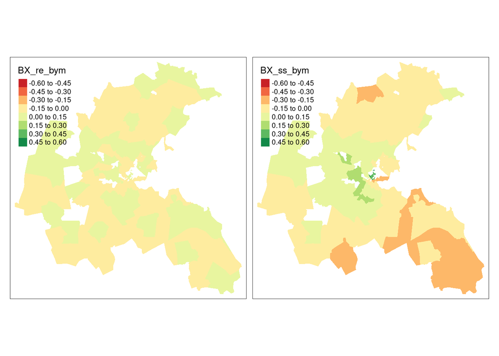

```r
tm_shape(b93) + tm_fill(c("BX_re_bym", "BX_ss_bym"), breaks=brks, midpoint=0)
```

### NOX coefficients

Looking at the NOX coefficients alone is disappointing, but recall that the upper level random effects do apply to NOX too so we could map their standard errors of which some are small compared to the effects:

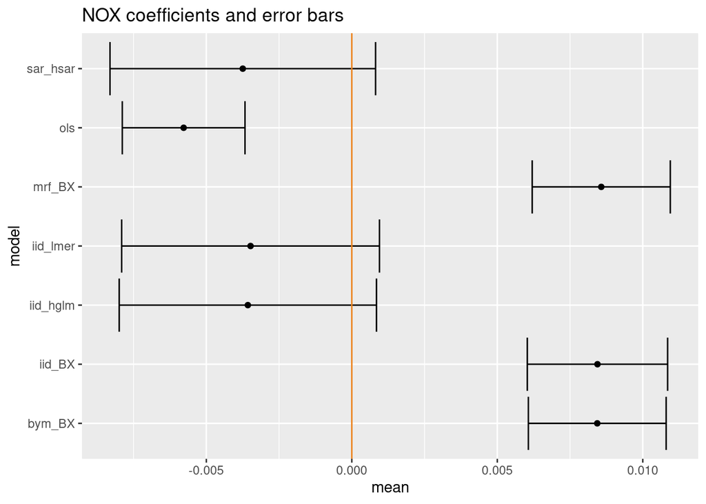

```r
library(ggplot2)
df_res <- as.data.frame(res)
names(df_res) <- c("mean", "sd")
limits <- aes(ymax = mean + qnorm(0.975)*sd, ymin=mean + qnorm(0.025)*sd)
df_res$model <- row.names(df_res)
p <- ggplot(df_res, aes(y=mean, x=model)) + geom_point() + geom_errorbar(limits) + geom_hline(yintercept = 0, col="#EB811B") + coord_flip()
p + ggtitle("NOX coefficients and error bars") + theme(plot.background = element_rect(fill = "transparent",colour = NA), legend.background = element_rect(colour = NA, fill = "transparent"))
```

# Bayesian spatial econometrics

```r
library(spdep)
```

```r
# install INLA
# install.packages("INLA", repos="https://inla.r-inla-download.org/R/stable")
library(INLA)
library(INLABMA)
```

### Columbus toy data

```r
data(oldcol)
lw <- nb2listw(COL.nb, style="W")
ev <- eigenw(similar.listw(lw))
W <- listw2mat(lw)
sW <- as(lw, "CsparseMatrix")
tr <- trW(sW)
m.form <-  CRIME ~ INC + HOVAL
COL.OLD$LAG_INC <- lag(lw, COL.OLD$INC)
COL.OLD$LAG_HOVAL <- lag(lw, COL.OLD$HOVAL)
COL.OLD$idx <- 1:nrow(COL.OLD)
dm.form <- CRIME ~ INC + HOVAL + LAG_INC + LAG_HOVAL
```

### Simulation framework

```r
titer <- 2000L
nomit <- 1000L
niter <- titer - nomit
thin <- 1L
```

### Check Durbin

```r
coefficients(lmSLX(m.form, data=COL.OLD, listw=lw))
```

```
## (Intercept)         INC       HOVAL     lag.INC   lag.HOVAL
##  75.0287479  -1.1089293  -0.2897283  -1.3709725   0.1917608
```

```r
coefficients(lm(dm.form, data=COL.OLD))
```

```
## (Intercept)         INC       HOVAL     LAG_INC   LAG_HOVAL
##  75.0287479  -1.1089293  -0.2897283  -1.3709725   0.1917608
```

### Try hglm

```r
library(hglm)
suppressWarnings(sem.hglm <- hglm(fixed=m.form, random= ~ 1 | I(as.factor(idx)),
                data=COL.OLD, rand.family=SAR(D=sW), sparse=TRUE, verbose=FALSE))
```

### HGLM SEM

```r
summary(sem.hglm)
```

```
## Call:
## hglm.formula(rand.family = SAR(D = sW), fixed = m.form, random = ~1 |
##     I(as.factor(idx)), data = COL.OLD, sparse = TRUE, verbose = FALSE)
##
## ----------
## MEAN MODEL
## ----------
##
## Summary of the fixed effects estimates:
##
##             Estimate Std. Error t-value Pr(>|t|)
## (Intercept) 62.50869    6.21608  10.056 6.99e-07 ***
## INC         -0.93132    0.33604  -2.771  0.01818 *
## HOVAL       -0.31695    0.09674  -3.276  0.00738 **
## ---
## Signif. codes:  0 '***' 0.001 '**' 0.01 '*' 0.05 '.' 0.1 ' ' 1
## Note: P-values are based on 11 degrees of freedom
##
## Summary of the random effects estimates:
##
##      Estimate Std. Error
## [1,]  -9.8292    32.5390
## [2,] -12.7254     5.7258
## [3,]  -1.8897     7.0867
## ...
## NOTE: to show all the random effects, use print(summary(hglm.object), print.ranef = TRUE).
##
## ----------------
## DISPERSION MODEL
## ----------------
##
## NOTE: h-likelihood estimates through EQL can be biased.
##
## Dispersion parameter for the mean model:
## [1] 22.30184
##
## Model estimates for the dispersion term:
##
## Link = log
##
```

[output cut: 9 more lines]

```
## Dispersion model for the random effects:
##
## Link = log
##
## Effects:
## .|Random1
##                        Estimate Std. Error
## 1/sqrt(SAR.tau)          0.1120     0.0144
## -SAR.rho/sqrt(SAR.tau)  -0.0813     0.0202
## SAR.tau (estimated spatial variance component): 79.67263
## SAR.rho (estimated spatial correlation): 0.7254112
##
## Dispersion = 1 is used in Gamma model on deviances to calculate the standard error(s).
##
## EQL estimation converged in 49 iterations.
```

### ML SEM

```r
sem.ml <- errorsarlm(m.form, data = COL.OLD, listw=lw, control=list(pre_eig=ev))
summary(sem.ml)
```

```
##
## Call:spatialreg::errorsarlm(formula = formula, data = data, listw = listw,
##     na.action = na.action, Durbin = Durbin, etype = etype, method = method,
##     quiet = quiet, zero.policy = zero.policy, interval = interval,
##     tol.solve = tol.solve, trs = trs, control = control)
##
## Residuals:
##       Min        1Q    Median        3Q       Max
## -34.81174  -6.44031  -0.72142   7.61476  23.33626
##
## Type: error
## Coefficients: (asymptotic standard errors)
##              Estimate Std. Error z value  Pr(>|z|)
## (Intercept) 59.893219   5.366163 11.1613 < 2.2e-16
## INC         -0.941312   0.330569 -2.8476 0.0044057
## HOVAL       -0.302250   0.090476 -3.3407 0.0008358
##
## Lambda: 0.56179, LR test value: 7.9935, p-value: 0.0046945
## Asymptotic standard error: 0.13387
##     z-value: 4.1966, p-value: 2.7098e-05
## Wald statistic: 17.611, p-value: 2.7098e-05
##
## Log likelihood: -183.3805 for error model
## ML residual variance (sigma squared): 95.575, (sigma: 9.7762)
## Number of observations: 49
## Number of parameters estimated: 5
## AIC: 376.76, (AIC for lm: 382.75)
```

### SET SEM (griddy Gibbs I)

```r
sem.SET0 <- spBreg_err(m.form, data = COL.OLD, listw=lw,
              control=list(ndraw=titer, nomit=nomit, prior=list(gG_sige=TRUE)))
summary(sem.SET0)
```

```
##
## Iterations = 1001:2000
## Thinning interval = 1
## Number of chains = 1
## Sample size per chain = 1000
##
## 1. Empirical mean and standard deviation for each variable,
##    plus standard error of the mean:
##
##                 Mean      SD Naive SE Time-series SE
## (Intercept)  59.6655  7.0906 0.224225       0.224225
## INC          -0.9503  0.4072 0.012876       0.013571
## HOVAL        -0.2986  0.1025 0.003240       0.003240
## lambda        0.5748  0.1574 0.004979       0.004979
## sige        115.7585 26.9444 0.852057       0.928068
##
## 2. Quantiles for each variable:
##
##                2.5%     25%      50%      75%     97.5%
## (Intercept) 44.9357 55.4516  60.0312  64.4074  73.14070
## INC         -1.7870 -1.2249  -0.9644  -0.6760  -0.15183
## HOVAL       -0.4968 -0.3661  -0.2988  -0.2360  -0.08375
## lambda       0.2336  0.4722   0.5878   0.6868   0.85400
## sige        74.7886 96.6315 112.0194 129.8980 177.65532
```

```r
library(coda)
raftery.diag(sem.SET0, r=0.01)
```

```
##
## Quantile (q) = 0.025
## Accuracy (r) = +/- 0.01
## Probability (s) = 0.95
##
##              Burn-in  Total Lower bound  Dependence
##              (M)      (N)   (Nmin)       factor (I)
##  (Intercept) 3        1053  937          1.120
##  INC         4        1243  937          1.330
##  HOVAL       2        893   937          0.953
##  lambda      2        893   937          0.953
##  sige        2        969   937          1.030
```

```r
geweke.diag(sem.SET0)
```

```
##
## Fraction in 1st window = 0.1
## Fraction in 2nd window = 0.5
##
## (Intercept)         INC       HOVAL      lambda        sige
##    -0.03977    -1.03947     0.15381    -0.86010    -1.33666
```

### SET SEM (griddy Gibbs II)

```r
sem.SET1 <- spBreg_err(m.form, data = COL.OLD, listw=lw,
              control=list(ndraw=titer, nomit=nomit, prior=list(gG_sige=FALSE)))
summary(sem.SET1)
```

```
##
## Iterations = 1001:2000
## Thinning interval = 1
## Number of chains = 1
## Sample size per chain = 1000
##
## 1. Empirical mean and standard deviation for each variable,
##    plus standard error of the mean:
##
##                 Mean       SD Naive SE Time-series SE
## (Intercept)  59.9714  6.90558 0.218374       0.218374
## INC          -0.9405  0.40445 0.012790       0.011363
## HOVAL        -0.3046  0.09882 0.003125       0.002987
## lambda        0.5605  0.16193 0.005121       0.005418
## sige        116.2834 26.97203 0.852931       0.918398
##
## 2. Quantiles for each variable:
##
##                2.5%     25%      50%      75%    97.5%
## (Intercept) 45.7257 55.2862  60.1940  64.7902  72.9389
## INC         -1.7327 -1.2044  -0.9510  -0.6747  -0.1353
## HOVAL       -0.4919 -0.3730  -0.3062  -0.2351  -0.1227
## lambda       0.2066  0.4617   0.5733   0.6768   0.8340
## sige        75.9857 97.0327 112.7933 131.7574 180.4995
```

```r
raftery.diag(sem.SET1, r=0.01)
```

```
##
## Quantile (q) = 0.025
## Accuracy (r) = +/- 0.01
## Probability (s) = 0.95
##
##              Burn-in  Total Lower bound  Dependence
##              (M)      (N)   (Nmin)       factor (I)
##  (Intercept) 2        893   937          0.953
##  INC         2        969   937          1.030
##  HOVAL       3        1053  937          1.120
##  lambda      2        969   937          1.030
##  sige        3        1143  937          1.220
```

```r
geweke.diag(sem.SET1)
```

```
##
## Fraction in 1st window = 0.1
## Fraction in 2nd window = 0.5
##
## (Intercept)         INC       HOVAL      lambda        sige
##      1.0520     -1.4527     -0.4592      0.4221      0.1536
```

### SET SEM (MH)

```r
sem.SET2 <- spBreg_err(m.form, data = COL.OLD, listw=lw,
              control=list(ndraw=titer, nomit=nomit, prior=list(lambdaMH=TRUE)))
summary(sem.SET2)
```

```
##
## Iterations = 1001:2000
## Thinning interval = 1
## Number of chains = 1
## Sample size per chain = 1000
##
## 1. Empirical mean and standard deviation for each variable,
##    plus standard error of the mean:
##
##                 Mean       SD Naive SE Time-series SE
## (Intercept)  59.3480  8.39304 0.265411       0.372207
## INC          -0.9118  0.41357 0.013078       0.018537
## HOVAL        -0.3023  0.09856 0.003117       0.003117
## lambda        0.6079  0.16825 0.005320       0.016357
## sige        118.1789 27.45061 0.868064       1.014923
##
## 2. Quantiles for each variable:
##
##                2.5%     25%      50%      75%    97.5%
## (Intercept) 42.1763 54.9426  59.7724  64.5145  73.7594
## INC         -1.7521 -1.1772  -0.9139  -0.6442  -0.1309
## HOVAL       -0.5034 -0.3682  -0.3022  -0.2373  -0.1155
## lambda       0.2193  0.5077   0.6278   0.7310   0.8995
## sige        75.6321 98.8037 114.6074 133.1394 188.0893
```

```r
raftery.diag(sem.SET2, r=0.01)
```

```
##
## Quantile (q) = 0.025
## Accuracy (r) = +/- 0.01
## Probability (s) = 0.95
##
##              Burn-in  Total Lower bound  Dependence
##              (M)      (N)   (Nmin)       factor (I)
##  (Intercept) 3        1053  937          1.12
##  INC         4        1243  937          1.33
##  HOVAL       3        1053  937          1.12
##  lambda      30       8231  937          8.78
##  sige        3        1053  937          1.12
```

```r
geweke.diag(sem.SET2)
```

```
##
## Fraction in 1st window = 0.1
## Fraction in 2nd window = 0.5
##
## (Intercept)         INC       HOVAL      lambda        sige
##      2.1174     -2.0423     -1.8097     -1.2677      0.6131
```

### INLA setup

```r
n <- nrow(COL.OLD)
rho.max <- 1/max(Re(ev))
rho.min <- 1/min(Re(ev))
rho <- mean(c(rho.min, rho.max))
```

### INLA_slm SEM setup

```r
zero.variance = list(prec=list(initial = 25, fixed=TRUE))
args.slm <- list(rho.min = rho.min, rho.max = rho.max, W = sW,
              X = matrix(0, nrow=n, ncol=0), Q.beta = matrix(1,0,0))
hyper.slm <- list(prec = list(prior = "loggamma", param = c(0.01, 0.01)),
              rho = list(initial=rho, prior = "logitbeta", param = c(1,1)))
```

### INLA_slm SEM

```r
system.time(sem.inla_slm <- inla(update(m.form, . ~ . + f(idx, model="slm",
                  args.slm=args.slm, hyper=hyper.slm)), data = COL.OLD,
                  family="gaussian", control.family = list(hyper=zero.variance),
                  control.compute=list(dic=TRUE, cpo=TRUE)))
print(summary(sem.inla_slm))
```

```
##
## Call:
##    c("inla(formula = update(m.form, . ~ . + f(idx, model = \"slm\",
##    args.slm = args.slm, ", " hyper = hyper.slm)), family = \"gaussian\",
##    data = COL.OLD, ", " control.compute = list(dic = TRUE, cpo = TRUE),
##    control.family = list(hyper = zero.variance))" )
## Time used:
##     Pre = 0.252, Running = 9.7, Post = 0.0552, Total = 10
## Fixed effects:
##               mean    sd 0.025quant 0.5quant 0.975quant   mode   kld
## (Intercept) 59.777 6.611     46.089   60.004     72.161 60.402 0.009
## INC         -0.940 0.383     -1.706   -0.936     -0.197 -0.927 0.000
## HOVAL       -0.301 0.095     -0.489   -0.301     -0.113 -0.302 0.000
##
## Random effects:
##   Name     Model
##     idx SLM model
##
## Model hyperparameters:
##                    mean    sd 0.025quant 0.5quant 0.975quant  mode
## Precision for idx 0.007 0.001      0.006    0.007      0.010 0.007
## Rho for idx       0.984 0.002      0.980    0.984      0.987 0.984
##
## Expected number of effective parameters(stdev): 49.00(0.00)
## Number of equivalent replicates : 1.00
##
## Deviance Information Criterion (DIC) ...............: -1036.71
## Deviance Information Criterion (DIC, saturated) ....: 98.23
## Effective number of parameters .....................: 48.91
##
## Marginal log-Likelihood:  -209.17
## CPO and PIT are computed
##
## Posterior marginals for the linear predictor and
##  the fitted values are computed
```

```r
ff<- function(z){z*(rho.max-rho.min)+rho.min}
semmarg <- inla.tmarginal(ff, sem.inla_slm$marginals.hyperpar[[2]])
c(mean=mean(semmarg[, "x"]), se=sd(semmarg[, "x"]))
```

```
##        mean          se
## 0.959359244 0.004720061
```

### SEM coefficients and SEs

```r
sem_res
```

```
##             sem_ml_coefs sem_hglm_coefs sem_SET0_coefs sem_SET1_coefs
## (Intercept)  59.89321925    62.50869055     59.6654639     59.9713625
##               5.36616252     6.21608063      7.0906116      6.9055791
## INC          -0.94131196    -0.93132065     -0.9502904     -0.9405358
##               0.33056857     0.33603590      0.4071690      0.4044485
## HOVAL        -0.30225021    -0.31694784     -0.2985719     -0.3046263
##               0.09047605     0.09674369      0.1024537      0.0988202
## lambda        0.56179027     0.72541120      0.5748174      0.5604862
##               0.13386868             NA      0.1574482      0.1619251
## s2           95.57450122             NA    115.7585288    116.2833583
##                       NA             NA     26.9444159     26.9720327
##             sem_SET2_coefs sem_inla_slm_coefs
## (Intercept)    59.34801837       59.777000000
##                 8.39304059        6.611000000
## INC            -0.91183903       -0.940000000
##                 0.41357101        0.383000000
## HOVAL          -0.30234932       -0.301000000
##                 0.09855563        0.095000000
## lambda          0.60794459        0.959359244
##                 0.16824755        0.004720061
## s2            118.17889654                 NA
##                27.45060806                 NA
```

### SDEM ML

```r
sdem.ml <- errorsarlm(m.form, data = COL.OLD, listw=lw, Durbin=TRUE,
            control=list(pre_eig=ev))
summary(sdem.ml)
```

```
##
## Call:spatialreg::errorsarlm(formula = formula, data = data, listw = listw,
##     na.action = na.action, Durbin = Durbin, etype = etype, method = method,
##     quiet = quiet, zero.policy = zero.policy, interval = interval,
##     tol.solve = tol.solve, trs = trs, control = control)
##
## Residuals:
##       Min        1Q    Median        3Q       Max
## -37.31635  -6.54376  -0.22212   6.44591  23.15801
##
## Type: error
## Coefficients: (asymptotic standard errors)
##              Estimate Std. Error z value  Pr(>|z|)
## (Intercept) 73.545133   8.783543  8.3731 < 2.2e-16
## INC         -1.051673   0.319514 -3.2915 0.0009966
## HOVAL       -0.275608   0.091151 -3.0236 0.0024976
## lag.INC     -1.156711   0.578629 -1.9991 0.0456024
## lag.HOVAL    0.111691   0.198993  0.5613 0.5746048
##
## Lambda: 0.4254, LR test value: 4.9871, p-value: 0.025537
## Asymptotic standard error: 0.15842
##     z-value: 2.6852, p-value: 0.0072485
## Wald statistic: 7.2103, p-value: 0.0072485
##
## Log likelihood: -181.5846 for error model
## ML residual variance (sigma squared): 92.531, (sigma: 9.6193)
## Number of observations: 49
## Number of parameters estimated: 7
## AIC: 377.17, (AIC for lm: 380.16)
```

```r
sdem.ml_imps <- summary(spdep::impacts(sdem.ml), zstats=TRUE, short=TRUE)
a1 <- expand.grid(colnames(sdem.ml_imps$mat), rownames(sdem.ml_imps$mat))
imp_nms <- c(t(cbind(paste(as.character(a1$Var1), as.character(a1$Var2), sep="_"),
            c(" ", "  ", "   ", "    ", "     ", "      "))))
print(sdem.ml_imps)
```

```
## Impact measures (SDEM, estimable, n):
##           Direct   Indirect      Total
## INC   -1.0516727 -1.1567109 -2.2083836
## HOVAL -0.2756084  0.1116912 -0.1639172
## ========================================================
## Standard errors:
##           Direct  Indirect     Total
## INC   0.31951388 0.5786287 0.6478636
## HOVAL 0.09115142 0.1989927 0.2346288
## ========================================================
## Z-values:
##          Direct   Indirect      Total
## INC   -3.291477 -1.9990554 -3.4087171
## HOVAL -3.023633  0.5612828 -0.6986236
##
## p-values:
##       Direct     Indirect Total
## INC   0.00099663 0.045602 0.00065269
## HOVAL 0.00249759 0.574605 0.48478731
```

### SDEM SET (griddy Gibbs I)

```r
system.time(sdem.SET0 <- spBreg_err(m.form, data = COL.OLD, listw=lw,
              Durbin=TRUE, control=list(ndraw=titer, nomit=nomit,
              prior=list(gG_sige=TRUE))))
```

```
##    user  system elapsed
##   1.295   0.004   1.762
```

```r
summary(sdem.SET0)
```

```
##
## Iterations = 1001:2000
## Thinning interval = 1
## Number of chains = 1
## Sample size per chain = 1000
##
## 1. Empirical mean and standard deviation for each variable,
##    plus standard error of the mean:
##
##                  Mean      SD Naive SE Time-series SE
## (Intercept)  73.23626 11.9263 0.377143       0.337229
## INC          -1.02841  0.3648 0.011535       0.011535
## HOVAL        -0.27636  0.1065 0.003367       0.003367
## lag.INC      -1.10646  0.7038 0.022256       0.022256
## lag.HOVAL     0.09539  0.2304 0.007286       0.007286
## lambda        0.48583  0.1749 0.005532       0.005532
## sige        114.08950 27.1255 0.857782       0.946701
##
## 2. Quantiles for each variable:
##
##                2.5%      25%      50%      75%     97.5%
## (Intercept) 49.6510 66.03792  74.0185  80.8360  96.56050
## INC         -1.7661 -1.25364  -1.0335  -0.8016  -0.29007
## HOVAL       -0.4857 -0.35033  -0.2771  -0.2048  -0.06866
## lag.INC     -2.4134 -1.52837  -1.1221  -0.6516   0.23323
## lag.HOVAL   -0.3563 -0.06062   0.1035   0.2506   0.52686
## lambda       0.1235  0.37969   0.4922   0.6128   0.80295
## sige        72.9631 94.87566 109.2733 128.6509 177.06057
```

```r
sdem.SET0_imps <- summary(spdep::impacts(sdem.SET0), zstats=TRUE, short=TRUE)
print(sdem.SET0_imps)
```

```
## Impact measures (SDEM, MCMC, n):
##           Direct    Indirect      Total
## INC   -1.0284092 -1.10645748 -2.1348667
## HOVAL -0.2763567  0.09538904 -0.1809677
## ========================================================
## Standard errors:
##          Direct  Indirect     Total
## INC   0.3456512 0.6669344 0.7845171
## HOVAL 0.1009014 0.2183391 0.2598518
## ========================================================
## Z-values:
##          Direct   Indirect      Total
## INC   -2.975280 -1.6590201 -2.7212493
## HOVAL -2.738878  0.4368849 -0.6964265
##
## p-values:
##       Direct    Indirect Total
## INC   0.0029272 0.097112 0.0065036
## HOVAL 0.0061649 0.662195 0.4861617
```

```r
raftery.diag(sdem.SET0, r=0.01)
```

```
##
## Quantile (q) = 0.025
## Accuracy (r) = +/- 0.01
## Probability (s) = 0.95
##
##              Burn-in  Total Lower bound  Dependence
##              (M)      (N)   (Nmin)       factor (I)
##  (Intercept) 2        969   937          1.030
##  INC         2        969   937          1.030
##  HOVAL       3        1053  937          1.120
##  lag.INC     2        969   937          1.030
##  lag.HOVAL   2        893   937          0.953
##  lambda      2        969   937          1.030
##  sige        2        969   937          1.030
```

```r
geweke.diag(sdem.SET0)
```

```
##
## Fraction in 1st window = 0.1
## Fraction in 2nd window = 0.5
##
## (Intercept)         INC       HOVAL     lag.INC   lag.HOVAL      lambda
##     0.23074    -0.06614     0.35521     0.06147    -0.55452    -1.85293
##        sige
##    -0.56234
```

### SDEM SET (griddy Gibbs II)

```r
sdem.SET1 <- spBreg_err(m.form, data = COL.OLD, listw=lw, Durbin=TRUE,
              control=list(ndraw=titer, nomit=nomit, prior=list(gG_sige=FALSE)))
summary(sdem.SET1)
```

```
##
## Iterations = 1001:2000
## Thinning interval = 1
## Number of chains = 1
## Sample size per chain = 1000
##
## 1. Empirical mean and standard deviation for each variable,
##    plus standard error of the mean:
##
##                  Mean      SD Naive SE Time-series SE
## (Intercept)  72.89261 11.8363 0.374297       0.374297
## INC          -1.01974  0.3643 0.011521       0.011521
## HOVAL        -0.27932  0.1025 0.003243       0.003243
## lag.INC      -1.06261  0.7489 0.023682       0.022513
## lag.HOVAL     0.08512  0.2409 0.007617       0.007617
## lambda        0.48794  0.1816 0.005743       0.005743
## sige        112.24814 24.9543 0.789125       0.872943
##
## 2. Quantiles for each variable:
##
##                 2.5%     25%       50%      75%     97.5%
## (Intercept) 46.99016 66.0477  73.05064  80.2474  94.75230
## INC         -1.71633 -1.2596  -1.02952  -0.7931  -0.28957
## HOVAL       -0.47257 -0.3515  -0.28403  -0.2102  -0.06573
## lag.INC     -2.48796 -1.5596  -1.08870  -0.5961   0.52117
## lag.HOVAL   -0.38758 -0.0698   0.09511   0.2376   0.56085
## lambda       0.09155  0.3717   0.50275   0.6178   0.80208
## sige        72.26621 95.5470 108.38555 126.3929 170.03477
```

```r
sdem.SET1_imps <- summary(spdep::impacts(sdem.SET1), zstats=TRUE, short=TRUE)
print(sdem.SET1_imps)
```

```
## Impact measures (SDEM, MCMC, n):
##           Direct    Indirect      Total
## INC   -1.0197355 -1.06261334 -2.0823488
## HOVAL -0.2793236  0.08512467 -0.1941989
## ========================================================
## Standard errors:
##           Direct  Indirect     Total
## INC   0.34522596 0.7096578 0.8379219
## HOVAL 0.09717594 0.2282498 0.2710770
## ========================================================
## Z-values:
##          Direct   Indirect      Total
## INC   -2.953820 -1.4973602 -2.4851347
## HOVAL -2.874411  0.3729452 -0.7163976
##
## p-values:
##       Direct    Indirect Total
## INC   0.0031387 0.13430  0.01295
## HOVAL 0.0040478 0.70919  0.47375
```

```r
raftery.diag(sdem.SET1, r=0.01)
```

```
##
## Quantile (q) = 0.025
## Accuracy (r) = +/- 0.01
## Probability (s) = 0.95
##
##              Burn-in  Total Lower bound  Dependence
##              (M)      (N)   (Nmin)       factor (I)
##  (Intercept) 2        893   937          0.953
##  INC         2        893   937          0.953
##  HOVAL       2        893   937          0.953
##  lag.INC     3        1053  937          1.120
##  lag.HOVAL   2        969   937          1.030
##  lambda      2        1001  937          1.070
##  sige        2        969   937          1.030
```

```r
geweke.diag(sdem.SET1)
```

```
##
## Fraction in 1st window = 0.1
## Fraction in 2nd window = 0.5
##
## (Intercept)         INC       HOVAL     lag.INC   lag.HOVAL      lambda
##      0.6556     -0.8839     -0.5818     -0.2817      0.3405     -1.6409
##        sige
##     -1.0795
```

### SDEM SET (MH)

```r
sdem.SET2 <- spBreg_err(m.form, data = COL.OLD, listw=lw, Durbin=TRUE,
              control=list(ndraw=titer, nomit=nomit, prior=list(lambdaMH=TRUE)))
summary(sdem.SET2)
```

```
##
## Iterations = 1001:2000
## Thinning interval = 1
## Number of chains = 1
## Sample size per chain = 1000
##
## 1. Empirical mean and standard deviation for each variable,
##    plus standard error of the mean:
##
##                  Mean      SD Naive SE Time-series SE
## (Intercept)  71.48994 18.6764 0.590601       0.547315
## INC          -0.97754  0.4004 0.012662       0.012662
## HOVAL        -0.27990  0.1085 0.003433       0.003593
## lag.INC      -0.93762  0.8654 0.027366       0.032643
## lag.HOVAL     0.06555  0.2612 0.008259       0.009395
## lambda        0.59316  0.1829 0.005784       0.015207
## sige        119.74915 28.5964 0.904297       1.110364
##
## 2. Quantiles for each variable:
##
##                2.5%      25%       50%      75%     97.5%
## (Intercept) 38.4712 63.01303  71.91837  80.2060 100.99259
## INC         -1.7283 -1.24252  -0.99279  -0.7094  -0.17632
## HOVAL       -0.5021 -0.35587  -0.27776  -0.2125  -0.06819
## lag.INC     -2.5092 -1.52750  -0.95760  -0.4268   0.89778
## lag.HOVAL   -0.5054 -0.08407   0.07039   0.2340   0.53478
## lambda       0.1559  0.48327   0.62050   0.7200   0.89173
## sige        76.3145 98.58220 115.56467 136.0698 189.45136
```

```r
sdem.SET2_imps <- summary(spdep::impacts(sdem.SET2), zstats=TRUE, short=TRUE)
print(sdem.SET2_imps)
```

```
## Impact measures (SDEM, MCMC, n):
##          Direct    Indirect      Total
## INC   -0.977545 -0.93761987 -1.9151649
## HOVAL -0.279900  0.06554672 -0.2143533
## ========================================================
## Standard errors:
##          Direct  Indirect     Total
## INC   0.3794209 0.8200480 1.0023543
## HOVAL 0.1028594 0.2474795 0.3053126
## ========================================================
## Z-values:
##          Direct   Indirect      Total
## INC   -2.576413 -1.1433720 -1.9106666
## HOVAL -2.721190  0.2648571 -0.7020783
##
## p-values:
##       Direct    Indirect Total
## INC   0.0099831 0.25288  0.056047
## HOVAL 0.0065047 0.79112  0.482630
```

```r
raftery.diag(sdem.SET2, r=0.01)
```

```
##
## Quantile (q) = 0.025
## Accuracy (r) = +/- 0.01
## Probability (s) = 0.95
##
##              Burn-in  Total Lower bound  Dependence
##              (M)      (N)   (Nmin)       factor (I)
##  (Intercept) 3        1053  937          1.120
##  INC         3        1053  937          1.120
##  HOVAL       2        893   937          0.953
##  lag.INC     3        1053  937          1.120
##  lag.HOVAL   4        1243  937          1.330
##  lambda      21       5611  937          5.990
##  sige        2        893   937          0.953
```

```r
geweke.diag(sdem.SET2)
```

```
##
## Fraction in 1st window = 0.1
## Fraction in 2nd window = 0.5
##
## (Intercept)         INC       HOVAL     lag.INC   lag.HOVAL      lambda
##    -0.07656    -1.44656    -0.59453    -0.17955     1.47442     0.75077
##        sige
##    -1.58498
```

### SDEM INLA_slm

```r
lc1 <- with(COL.OLD, inla.make.lincomb(INC=+1, LAG_INC=+1))
names(lc1) <- "TOT_INC"
lc2 <- with(COL.OLD, inla.make.lincomb(HOVAL=+1, LAG_HOVAL=+1))
names(lc2) <- "TOT_HOVAL"
```

```r
system.time(sdem.inla_slm <- inla(update(dm.form, . ~ . + f(idx, model="slm",
                  args.slm=args.slm, hyper=hyper.slm)), data = COL.OLD,
                  lincomb = c(lc1, lc2),
                  family="gaussian", control.family = list(hyper=zero.variance),
                  control.compute=list(dic=TRUE, cpo=TRUE, config=TRUE)))
```

```r
print(summary(sdem.inla_slm))
```

```
##
## Call:
##    c("inla(formula = update(dm.form, . ~ . + f(idx, model = \"slm\", ", "
##    args.slm = args.slm, hyper = hyper.slm)), family = \"gaussian\", ", "
##    data = COL.OLD, lincomb = c(lc1, lc2), control.compute = list(dic =
##    TRUE, ", " cpo = TRUE, config = TRUE), control.family = list(hyper =
##    zero.variance))" )
## Time used:
##     Pre = 0.215, Running = 2.9, Post = 1.08, Total = 4.19
## Fixed effects:
##               mean     sd 0.025quant 0.5quant 0.975quant   mode   kld
## (Intercept) 66.400 21.139     24.194   66.527    107.783 66.718 0.003
## INC         -0.827  0.417     -1.646   -0.829     -0.002 -0.831 0.000
## HOVAL       -0.298  0.115     -0.525   -0.298     -0.073 -0.298 0.000
## LAG_INC     -0.547  0.968     -2.445   -0.551      1.370 -0.558 0.000
## LAG_HOVAL   -0.014  0.265     -0.539   -0.014      0.507 -0.013 0.000
##
## Linear combinations (derived):
##           ID   mean    sd 0.025quant 0.5quant 0.975quant   mode kld
## TOT_INC    1 -1.375 1.261     -3.844   -1.380      1.125 -1.390   0
## TOT_HOVAL  2 -0.313 0.348     -1.000   -0.312      0.370 -0.311   0
##
## Random effects:
##   Name     Model
##     idx SLM model
##
## Model hyperparameters:
##                    mean    sd 0.025quant 0.5quant 0.975quant  mode
## Precision for idx 0.010 0.003      0.007    0.009      0.017 0.008
## Rho for idx       0.986 0.002      0.983    0.986      0.989 0.986
##
## Expected number of effective parameters(stdev): 49.00(0.00)
## Number of equivalent replicates : 1.00
##
## Deviance Information Criterion (DIC) ...............: -1036.71
## Deviance Information Criterion (DIC, saturated) ....: 98.23
## Effective number of parameters .....................: 48.91
##
## Marginal log-Likelihood:  -217.12
## CPO and PIT are computed
##
## Posterior marginals for the linear predictor and
##  the fitted values are computed
```

```r
sdemmarg <- inla.tmarginal(ff, sdem.inla_slm$marginals.hyperpar[[2]])
c(mean=mean(sdemmarg[, "x"]), se=sd(sdemmarg[, "x"]))
```

```
##        mean          se
## 0.964827109 0.004395237
```

```r
system.time(mc.samples <- inla.posterior.sample(niter, sdem.inla_slm))
```

```
##    user  system elapsed
##   9.851   2.118  14.751
```

```r
smple0 <- t(sapply(mc.samples, function(x) x$latent[100:103]))
colnames(smple0) <- c("Direct_LAG", "Direct_HOVAL", "Indirect_LAG", "Indirect_HOVAL")
smple <- cbind(smple0, Total_LAG=smple0[,1]+smple0[,3], Total_HOVAL=smple0[,2]+smple0[,4])
```

```r
(sdem.inla_mc_imps1 <- apply(smple, 2, mean)[c(1,3,5,2,4,6)])
```

```
##     Direct_LAG   Indirect_LAG      Total_LAG   Direct_HOVAL Indirect_HOVAL
##    -0.81155586    -0.53611877    -1.34767464    -0.30597987    -0.03166045
##    Total_HOVAL
##    -0.33764032
```

```r
(sdem.inla_mc_imps2 <- apply(smple, 2, sd)[c(1,3,5,2,4,6)])
```

```
##     Direct_LAG   Indirect_LAG      Total_LAG   Direct_HOVAL Indirect_HOVAL
##      0.4276475      1.0153804      1.3156905      0.1166491      0.2636955
##    Total_HOVAL
##      0.3448504
```

### SDEM coefficients

```r
sdem_res
```

```
##             sdem_ml_coefs sdem_SET0_coefs sdem_SET1_coefs sdem_SET2_coefs
## (Intercept)   73.54513284     73.23625923     72.89260661     71.48993731
##                8.78354327     11.92631944     11.83631058     18.67643406
## INC           -1.05167269     -1.02840923     -1.01973549     -0.97754499
##                0.31951388      0.36476216      0.36431340      0.40039897
## HOVAL         -0.27560842     -0.27635674     -0.27932359     -0.27990005
##                0.09115142      0.10648025      0.10254877      0.10854648
## lag.INC       -1.15671090     -1.10645748     -1.06261334     -0.93761987
##                0.57862875      0.70380896      0.74889455      0.86538816
## lag.HOVAL      0.11169118      0.09538904      0.08512467      0.06554672
##                0.19899272      0.23041098      0.24086966      0.26116260
## lambda         0.42539901      0.48582891      0.48794097      0.59316177
##                0.15842312      0.17493501      0.18159575      0.18291470
## s2            92.53089974    114.08950088    112.24814156    119.74915463
##                        NA     27.12546333     24.95433284     28.59637842
##             sdem_inla_slm_coefs
## (Intercept)        66.400000000
##                    21.139000000
## INC                -0.827000000
##                     0.417000000
## HOVAL              -0.298000000
##                     0.115000000
## lag.INC            -0.547000000
##                     0.968000000
## lag.HOVAL          -0.014000000
##                     0.265000000
## lambda              0.964827109
##                     0.004395237
## s2                           NA
##                              NA
```

### SDEM impacts

```r
print(sdem_imp_res)
```

```
##                    sdem.ml   sdem.SET0   sdem.SET1   sdem.SET2 sdem.inla_slm_lc
## Direct_INC     -1.05167269 -1.02840923 -1.01973549 -0.97754499       -0.8270000
##                 0.31951388  0.34565121  0.34522596  0.37942090        0.4170000
## Indirect_INC   -1.15671090 -1.10645748 -1.06261334 -0.93761987       -0.5470000
##                 0.57862875  0.66693435  0.70965778  0.82004795        0.9680000
## Total_INC      -2.20838359 -2.13486671 -2.08234882 -1.91516486       -1.3747765
##                 0.64786356  0.78451714  0.83792191  1.00235427        1.2605325
## Direct_HOVAL   -0.27560842 -0.27635674 -0.27932359 -0.27990005       -0.2980000
##                 0.09115142  0.10090144  0.09717594  0.10285941        0.1150000
## Indirect_HOVAL  0.11169118  0.09538904  0.08512467  0.06554672       -0.0140000
##                 0.19899272  0.21833908  0.22824980  0.24747953        0.2650000
## Total_HOVAL    -0.16391724 -0.18096770 -0.19419892 -0.21435333       -0.3125199
##                 0.23462885  0.25985181  0.27107703  0.30531256        0.3477132
##                sdem.inla_mc
## Direct_INC      -0.81155586
##                  0.42764751
## Indirect_INC    -0.53611877
##                  1.01538044
## Total_INC       -1.34767464
##                  1.31569051
## Direct_HOVAL    -0.30597987
##                  0.11664914
## Indirect_HOVAL  -0.03166045
##                  0.26369546
## Total_HOVAL     -0.33764032
##                  0.34485043
```

### SLM ML

```r
slm.ml <- lagsarlm(m.form, data = COL.OLD, listw=lw, control=list(pre_eig=ev))
summary(slm.ml)
```

```
##
## Call:spatialreg::lagsarlm(formula = formula, data = data, listw = listw,
##     na.action = na.action, Durbin = Durbin, type = type, method = method,
##     quiet = quiet, zero.policy = zero.policy, interval = interval,
##     tol.solve = tol.solve, trs = trs, control = control)
##
## Residuals:
##       Min        1Q    Median        3Q       Max
## -37.68585  -5.35636   0.05421   6.02013  23.20555
##
## Type: lag
## Coefficients: (asymptotic standard errors)
##              Estimate Std. Error z value  Pr(>|z|)
## (Intercept) 45.079251   7.177347  6.2808 3.369e-10
## INC         -1.031616   0.305143 -3.3808 0.0007229
## HOVAL       -0.265926   0.088499 -3.0049 0.0026570
##
## Rho: 0.43102, LR test value: 9.9736, p-value: 0.001588
## Asymptotic standard error: 0.11768
##     z-value: 3.6626, p-value: 0.00024962
## Wald statistic: 13.415, p-value: 0.00024962
##
## Log likelihood: -182.3904 for lag model
## ML residual variance (sigma squared): 95.494, (sigma: 9.7721)
## Number of observations: 49
## Number of parameters estimated: 5
## AIC: 374.78, (AIC for lm: 382.75)
## LM test for residual autocorrelation
## test value: 0.31955, p-value: 0.57188
```

```r
slm.ml_imps <- summary(spdep::impacts(slm.ml, tr=tr, R=1000), zstats=TRUE, short=TRUE)
print(slm.ml_imps)
```

```
## Impact measures (lag, trace):
##           Direct   Indirect      Total
## INC   -1.0860220 -0.7270848 -1.8131068
## HOVAL -0.2799509 -0.1874253 -0.4673763
## ========================================================
## Simulation results (asymptotic variance matrix):
## ========================================================
## Simulated standard errors
##           Direct  Indirect     Total
## INC   0.30471901 0.3985925 0.5958901
## HOVAL 0.09451098 0.1302795 0.2000298
##
## Simulated z-values:
##          Direct  Indirect     Total
## INC   -3.578300 -1.939915 -3.127441
## HOVAL -2.992097 -1.583523 -2.445070
##
## Simulated p-values:
##       Direct     Indirect Total
## INC   0.00034584 0.05239  0.0017633
## HOVAL 0.00277068 0.11330  0.0144824
```

### SLM SET (griddy Gibbs)

```r
system.time(slm.SET0 <- spBreg_lag(m.form, data = COL.OLD, listw=lw,
              control=list(ndraw=titer, nomit=nomit)))
```

```
##    user  system elapsed
##   1.219   0.010   1.482
```

```r
summary(slm.SET0)
```

```
##
## Iterations = 1001:2000
## Thinning interval = 1
## Number of chains = 1
## Sample size per chain = 1000
##
## 1. Empirical mean and standard deviation for each variable,
##    plus standard error of the mean:
##
##                 Mean       SD Naive SE Time-series SE
## (Intercept)  46.1597  7.98594 0.252538       0.252538
## INC          -1.0476  0.33365 0.010551       0.011128
## HOVAL        -0.2682  0.09402 0.002973       0.002973
## rho           0.4117  0.12535 0.003964       0.003964
## sige        107.5685 24.15748 0.763927       0.835166
##
## 2. Quantiles for each variable:
##
##                2.5%     25%      50%      75%    97.5%
## (Intercept) 30.7707 40.6710  46.1353  51.5375  62.6429
## INC         -1.6747 -1.2640  -1.0620  -0.8227  -0.3938
## HOVAL       -0.4508 -0.3308  -0.2706  -0.2050  -0.0874
## rho          0.1586  0.3237   0.4137   0.4967   0.6428
## sige        70.8142 89.9821 103.5887 120.7043 161.7662
```

```r
slm.SET0_imps <- summary(spdep::impacts(slm.SET0, tr=tr), zstats=TRUE, short=TRUE)
print(slm.SET0_imps)
```

```
## Impact measures (lag, trace):
##           Direct   Indirect      Total
## INC   -1.0971095 -0.6836177 -1.7807272
## HOVAL -0.2808796 -0.1750183 -0.4558979
## ========================================================
## MCMC sample impact results:
## ========================================================
## Simulated standard errors
##          Direct  Indirect     Total
## INC   0.3546421 0.4768169 0.7460270
## HOVAL 0.1004464 0.1327925 0.2117388
##
## Simulated z-values:
##          Direct  Indirect     Total
## INC   -3.120641 -1.601709 -2.507192
## HOVAL -2.823138 -1.490127 -2.273800
##
## Simulated p-values:
##       Direct    Indirect Total
## INC   0.0018046 0.10922  0.012169
## HOVAL 0.0047556 0.13619  0.022978
```

```r
raftery.diag(slm.SET0, r=0.01)
```

```
##
## Quantile (q) = 0.025
## Accuracy (r) = +/- 0.01
## Probability (s) = 0.95
##
##              Burn-in  Total Lower bound  Dependence
##              (M)      (N)   (Nmin)       factor (I)
##  (Intercept) 2        893   937          0.953
##  INC         5        1353  937          1.440
##  HOVAL       2        969   937          1.030
##  rho         2        926   937          0.988
##  sige        2        893   937          0.953
```

```r
geweke.diag(slm.SET0)
```

```
##
## Fraction in 1st window = 0.1
## Fraction in 2nd window = 0.5
##
## (Intercept)         INC       HOVAL         rho        sige
##      0.3500     -1.3420      0.2971      0.2188      0.3943
```

### SLM SET (MH)

```r
system.time(slm.SET1 <- spBreg_lag(m.form, data = COL.OLD, listw=lw,
              control=list(ndraw=titer, nomit=nomit, prior=list(rhoMH=TRUE))))
```

```
##    user  system elapsed
##   1.119   0.002   1.354
```

```r
summary(slm.SET1)
```

```
##
## Iterations = 1001:2000
## Thinning interval = 1
## Number of chains = 1
## Sample size per chain = 1000
##
## 1. Empirical mean and standard deviation for each variable,
##    plus standard error of the mean:
##
##                 Mean       SD Naive SE Time-series SE
## (Intercept)  45.5022  9.44863 0.298792       3.132008
## INC          -1.0501  0.35546 0.011240       0.050058
## HOVAL        -0.2618  0.09113 0.002882       0.002746
## rho           0.4224  0.15361 0.004858       0.060820
## sige        109.4423 24.94303 0.788768       1.311105
##
## 2. Quantiles for each variable:
##
##                2.5%     25%      50%      75%     97.5%
## (Intercept) 27.9862 39.0283  44.5738  51.5005  66.05717
## INC         -1.7810 -1.2997  -1.0434  -0.8070  -0.40263
## HOVAL       -0.4379 -0.3202  -0.2621  -0.2012  -0.08612
## rho          0.1017  0.3472   0.4337   0.5360   0.69481
## sige        72.1076 91.4155 105.4202 124.0081 170.13856
```

```r
slm.SET1_imps <- summary(spdep::impacts(slm.SET1, tr=tr), zstats=TRUE, short=TRUE)
print(slm.SET1_imps)
```

```
## Impact measures (lag, trace):
##          Direct   Indirect     Total
## INC   -1.102863 -0.7152633 -1.818126
## HOVAL -0.274979 -0.1783380 -0.453317
## ========================================================
## MCMC sample impact results:
## ========================================================
## Simulated standard errors
##           Direct  Indirect     Total
## INC   0.35445400 0.4057769 0.5780082
## HOVAL 0.09721699 0.1495095 0.2190870
##
## Simulated z-values:
##          Direct  Indirect     Total
## INC   -3.126849 -1.838822 -3.208391
## HOVAL -2.864605 -1.389030 -2.219033
##
## Simulated p-values:
##       Direct    Indirect Total
## INC   0.0017669 0.065941 0.0013348
## HOVAL 0.0041753 0.164824 0.0264845
```

```r
raftery.diag(slm.SET1, r=0.01)
```

```
##
## Quantile (q) = 0.025
## Accuracy (r) = +/- 0.01
## Probability (s) = 0.95
##
##              Burn-in  Total Lower bound  Dependence
##              (M)      (N)   (Nmin)       factor (I)
##  (Intercept) 8        1392  937           1.490
##  INC         3        1053  937           1.120
##  HOVAL       2        893   937           0.953
##  rho         81       21990 937          23.500
##  sige        2        893   937           0.953
```

```r
geweke.diag(slm.SET1)
```

```
##
## Fraction in 1st window = 0.1
## Fraction in 2nd window = 0.5
##
## (Intercept)         INC       HOVAL         rho        sige
##     0.05794    -0.08733    -0.26178    -0.04533     0.17372
```

### SLM INLA_slm

```r
mm <- model.matrix(m.form, data=COL.OLD)
betaprec <- .0001
Q.beta = Diagonal(n=ncol(mm), betaprec)
args.slm <- list(rho.min = rho.min, rho.max = rho.max, W = sW, X = mm, Q.beta = Q.beta)
system.time(slm.inla_slm <- inla(CRIME ~ 0 + f(idx, model="slm",
                  args.slm=args.slm, hyper=hyper.slm), data = COL.OLD,
                  family="gaussian", control.family = list(hyper=zero.variance),
                  control.compute=list(dic=TRUE, cpo=TRUE, config=TRUE)))
```

```r
print(summary(slm.inla_slm))
```

```
##
## Call:
##    c("inla(formula = CRIME ~ 0 + f(idx, model = \"slm\", args.slm =
##    args.slm, ", " hyper = hyper.slm), family = \"gaussian\", data =
##    COL.OLD, ", " control.compute = list(dic = TRUE, cpo = TRUE, config =
##    TRUE), ", " control.family = list(hyper = zero.variance))")
## Time used:
##     Pre = 0.189, Running = 4.01, Post = 1.71, Total = 5.91
## Random effects:
##   Name     Model
##     idx SLM model
##
## Model hyperparameters:
##                   mean    sd 0.025quant 0.5quant 0.975quant mode
## Precision for idx 0.01 0.001      0.007     0.01      0.012 0.01
## Rho for idx       0.98 0.003      0.975     0.98      0.985 0.98
##
## Expected number of effective parameters(stdev): 49.00(0.00)
## Number of equivalent replicates : 1.00
##
## Deviance Information Criterion (DIC) ...............: -1036.71
## Deviance Information Criterion (DIC, saturated) ....: 98.23
## Effective number of parameters .....................: 48.91
##
## Marginal log-Likelihood:  -221.85
## CPO and PIT are computed
##
## Posterior marginals for the linear predictor and
##  the fitted values are computed
```

```r
slmmarg <- inla.tmarginal(ff, slm.inla_slm$marginals.hyperpar[[2]])
c(mean=mean(slmmarg[, "x"]), se=sd(slmmarg[, "x"]))
```

```
##        mean          se
## 0.949311874 0.006493062
```

```r
slm.inla_slm$summary.random$idx[n+1:ncol(mm),]
```

```
##    ID       mean         sd 0.025quant  0.5quant  0.975quant       mode
## 50 50 46.8648643 7.77761316 30.9707182 47.140555 61.57741823 47.8779716
## 51 51 -1.0729371 0.34201393 -1.7482384 -1.072058 -0.40273462 -1.0705042
## 52 52 -0.2659307 0.09417883 -0.4514877 -0.265899 -0.08069812 -0.2658252
##             kld
## 50 1.328082e-03
## 51 1.935619e-04
## 52 1.522107e-05
```

```r
system.time(mc.samples <- inla.posterior.sample(niter, slm.inla_slm))
```

```
##    user  system elapsed
##   4.135   2.038   7.516
```

```r
smples0 <- t(sapply(mc.samples, function(x) c(x$latent[99:101],
                                              ff(x$hyperpar[2]), 0)))
colnames(smples0) <- c("(Intercept)", "INC", "HOVAL", "rho", "sige")
smples <- as.mcmc(smples0)
attr(smples, "listw_style") <- "W"
attr(smples, "control")$interval <- c(rho.min, rho.max)
attr(smples, "type") <- "lag"
slm.inla_slm_imps <- summary(spdep:::impacts.MCMC_sar_g(smples, tr=tr),
                             zstats=TRUE, short=TRUE)
print(slm.inla_slm_imps)
```

```
## Impact measures (lag, trace):
##           Direct   Indirect     Total
## INC   -1.1173914 -0.6621979 -1.779589
## HOVAL -0.2792434 -0.1654876 -0.444731
## ========================================================
## Simulation results ( variance matrix):
## ========================================================
## Simulated standard errors
##          Direct  Indirect     Total
## INC   0.3363421 0.3609525 0.5603895
## HOVAL 0.1002730 0.1251009 0.2007521
##
## Simulated z-values:
##          Direct  Indirect     Total
## INC   -3.333633 -1.904389 -3.227462
## HOVAL -2.806064 -1.466331 -2.315351
##
## Simulated p-values:
##       Direct    Indirect Total
## INC   0.0008572 0.056859 0.0012489
## HOVAL 0.0050151 0.142558 0.0205937
```

### SLM coefficients

```r
slm_res
```

```
##             slm_ml_coefs slm_SET0_coefs slm_SET1_coefs slm_inla_slm_coefs
## (Intercept)  45.07925051    46.15965704    45.50223622       46.864864349
##               7.17734654     7.98594235     9.44863488        7.777613163
## INC          -1.03161570    -1.04757001    -1.05008260       -1.072937131
##               0.30514297     0.33365234     0.35545555        0.342013925
## HOVAL        -0.26592625    -0.26819657    -0.26181918       -0.265930742
##               0.08849862     0.09401917     0.09112631        0.094178833
## rho           0.43102320     0.41171786     0.42243692        0.949311874
##               0.11768073     0.12534725     0.15361449        0.006493062
## s2           95.49449671   107.56851570   109.44233585                 NA
##                       NA    24.15748185    24.94303055                 NA
```

### SLM impacts

```r
print(slm_imp_res)
```

```
##                     slm.ml   slm.SET0 slm.SET1_impv slm.inla_slm
## Direct_INC     -1.08602200 -1.0971095   -1.10286295   -1.1173914
##                 0.30471901  0.3546421    0.35445400    0.3363421
## Indirect_INC   -0.72708479 -0.6836177   -0.71526330   -0.6621979
##                 0.39859247  0.4768169    0.40577691    0.3609525
## Total_INC      -1.81310679 -1.7807272   -1.81812625   -1.7795893
##                 0.59589015  0.7460270    0.57800818    0.5603895
## Direct_HOVAL   -0.27995092 -0.2808796   -0.27497901   -0.2792434
##                 0.09451098  0.1004464    0.09721699    0.1002730
## Indirect_HOVAL -0.18742535 -0.1750183   -0.17833802   -0.1654876
##                 0.13027953  0.1327925    0.14950946    0.1251009
## Total_HOVAL    -0.46737627 -0.4558979   -0.45331703   -0.4447310
##                 0.20002977  0.2117388    0.21908702    0.2007521
```

### SDM ML

```r
sdm.ml <- lagsarlm(m.form, data = COL.OLD, listw=lw, Durbin=TRUE,
            control=list(pre_eig=ev))
summary(sdm.ml)
```

```
##
## Call:spatialreg::lagsarlm(formula = formula, data = data, listw = listw,
##     na.action = na.action, Durbin = Durbin, type = type, method = method,
##     quiet = quiet, zero.policy = zero.policy, interval = interval,
##     tol.solve = tol.solve, trs = trs, control = control)
##
## Residuals:
##       Min        1Q    Median        3Q       Max
## -37.47829  -6.46731  -0.33835   6.05200  22.62969
##
## Type: mixed
## Coefficients: (asymptotic standard errors)
##              Estimate Std. Error z value  Pr(>|z|)
## (Intercept) 42.822415  12.667205  3.3806 0.0007233
## INC         -0.914223   0.331094 -2.7612 0.0057586
## HOVAL       -0.293738   0.089212 -3.2926 0.0009927
## lag.INC     -0.520284   0.565129 -0.9206 0.3572355
## lag.HOVAL    0.245640   0.178917  1.3729 0.1697756
##
## Rho: 0.42634, LR test value: 5.3693, p-value: 0.020494
## Asymptotic standard error: 0.15623
##     z-value: 2.7288, p-value: 0.0063561
## Wald statistic: 7.4465, p-value: 0.0063561
##
## Log likelihood: -181.3935 for mixed model
## ML residual variance (sigma squared): 91.791, (sigma: 9.5808)
## Number of observations: 49
## Number of parameters estimated: 7
## AIC: 376.79, (AIC for lm: 380.16)
## LM test for residual autocorrelation
## test value: 0.28919, p-value: 0.59074
```

```r
sdm.ml_imps <- summary(spdep::impacts(sdm.ml, tr=tr, R=1000), zstats=TRUE, short=TRUE)
print(sdm.ml_imps)
```

```
## Impact measures (mixed, trace):
##           Direct  Indirect       Total
## INC   -1.0238910 -1.476711 -2.50060224
## HOVAL -0.2792275  0.195385 -0.08384256
## ========================================================
## Simulation results (asymptotic variance matrix):
## ========================================================
## Simulated standard errors
##           Direct  Indirect     Total
## INC   0.32674440 0.8981027 0.9549842
## HOVAL 0.09604681 0.3360752 0.3735939
##
## Simulated z-values:
##          Direct   Indirect      Total
## INC   -3.156666 -1.7255097 -2.7027755
## HOVAL -2.909487  0.6224116 -0.1880914
##
## Simulated p-values:
##       Direct    Indirect Total
## INC   0.0015958 0.084436 0.0068763
## HOVAL 0.0036202 0.533671 0.8508050
```

### SDM SET (griddy Gibbs)

```r
system.time(sdm.SET0 <- spBreg_lag(m.form, data = COL.OLD, listw=lw, Durbin=TRUE,
              control=list(ndraw=titer, nomit=nomit)))
```

```
##    user  system elapsed
##   1.268   0.010   1.539
```

```r
summary(sdm.SET0)
```

```
##
## Iterations = 1001:2000
## Thinning interval = 1
## Number of chains = 1
## Sample size per chain = 1000
##
## 1. Empirical mean and standard deviation for each variable,
##    plus standard error of the mean:
##
##                 Mean       SD Naive SE Time-series SE
## (Intercept)  46.1734 14.42825 0.456261       0.456261
## INC          -0.9488  0.35659 0.011276       0.011848
## HOVAL        -0.2923  0.09608 0.003038       0.003038
## lag.INC      -0.6056  0.63426 0.020057       0.017655
## lag.HOVAL     0.2425  0.19504 0.006168       0.006168
## rho           0.3827  0.17079 0.005401       0.005401
## sige        108.7664 24.15386 0.763812       0.831147
##
## 2. Quantiles for each variable:
##
##                2.5%     25%      50%      75%    97.5%
## (Intercept) 18.3707 36.5116  46.2464  56.0413  73.3293
## INC         -1.6436 -1.1893  -0.9455  -0.7021  -0.2665
## HOVAL       -0.4841 -0.3565  -0.2924  -0.2259  -0.1023
## lag.INC     -1.8914 -1.0222  -0.6159  -0.1665   0.6072
## lag.HOVAL   -0.1436  0.1113   0.2434   0.3763   0.6346
## rho          0.0495  0.2634   0.3852   0.5008   0.7209
## sige        68.6396 91.3484 106.5643 123.2990 164.2435
```

```r
sdm.SET0_imps <- summary(spdep::impacts(sdm.SET0, tr=tr), zstats=TRUE, short=TRUE)
print(sdm.SET0_imps)
```

```
## Impact measures (mixed, trace):
##           Direct  Indirect       Total
## INC   -1.0497653 -1.468611 -2.51837611
## HOVAL -0.2787055  0.198048 -0.08065754
## ========================================================
## MCMC sample impact results:
## ========================================================
## Simulated standard errors
##          Direct  Indirect    Total
## INC   0.3699554 1.3500616 1.481072
## HOVAL 0.1002762 0.3342742 0.371193
##
## Simulated z-values:
##          Direct   Indirect      Total
## INC   -2.901460 -1.2498891 -1.8640809
## HOVAL -2.799422  0.5725709 -0.2406292
##
## Simulated p-values:
##       Direct    Indirect Total
## INC   0.0037143 0.21134  0.06231
## HOVAL 0.0051194 0.56694  0.80984
```

```r
raftery.diag(sdm.SET0, r=0.01)
```

```
##
## Quantile (q) = 0.025
## Accuracy (r) = +/- 0.01
## Probability (s) = 0.95
##
##              Burn-in  Total Lower bound  Dependence
##              (M)      (N)   (Nmin)       factor (I)
##  (Intercept) 2        893   937          0.953
##  INC         2        969   937          1.030
##  HOVAL       2        893   937          0.953
##  lag.INC     2        969   937          1.030
##  lag.HOVAL   2        969   937          1.030
##  rho         2        892   937          0.952
##  sige        2        893   937          0.953
```

```r
geweke.diag(sdm.SET0)
```

```
##
## Fraction in 1st window = 0.1
## Fraction in 2nd window = 0.5
##
## (Intercept)         INC       HOVAL     lag.INC   lag.HOVAL         rho
##     0.68447     1.50458     0.01505    -1.61501    -0.92401     0.01812
##        sige
##    -1.08054
```

### SDM SET (MH)

```r
system.time(sdm.SET1 <- spBreg_lag(m.form, data = COL.OLD, listw=lw, Durbin=TRUE,
              control=list(ndraw=titer, nomit=nomit, prior=list(rhoMH=TRUE))))
```

```
##    user  system elapsed
##   1.136   0.000   1.311
```

```r
summary(sdm.SET1)
```

```
##
## Iterations = 1001:2000
## Thinning interval = 1
## Number of chains = 1
## Sample size per chain = 1000
##
## 1. Empirical mean and standard deviation for each variable,
##    plus standard error of the mean:
##
##                 Mean       SD Naive SE Time-series SE
## (Intercept)  41.2210 16.15206 0.510773       4.902224
## INC          -0.9045  0.36757 0.011624       0.022824
## HOVAL        -0.2895  0.09718 0.003073       0.002924
## lag.INC      -0.4725  0.64775 0.020484       0.106667
## lag.HOVAL     0.2414  0.19506 0.006168       0.006565
## rho           0.4468  0.19470 0.006157       0.067514
## sige        109.1776 25.33553 0.801180       1.174343
##
## 2. Quantiles for each variable:
##
##                2.5%     25%      50%       75%     97.5%
## (Intercept) 16.5622 28.8492  38.1592  52.01227  75.61667
## INC         -1.6076 -1.1335  -0.9014  -0.65948  -0.19542
## HOVAL       -0.4824 -0.3538  -0.2918  -0.22471  -0.09752
## lag.INC     -1.7331 -0.9093  -0.4525  -0.02647   0.76277
## lag.HOVAL   -0.1541  0.1118   0.2421   0.37790   0.61618
## rho          0.0143  0.3241   0.5000   0.61018   0.70265
## sige        71.0624 91.3227 105.5074 123.00343 168.45574
```

```r
sdm.SET1_imps <- summary(spdep::impacts(sdm.SET1, tr=tr), zstats=TRUE, short=TRUE)
print(sdm.SET1_imps)
```

```
## Impact measures (mixed, trace):
##           Direct   Indirect       Total
## INC   -1.0173178 -1.4718182 -2.48913606
## HOVAL -0.2750354  0.1881479 -0.08688758
## ========================================================
## MCMC sample impact results:
## ========================================================
## Simulated standard errors
##          Direct  Indirect     Total
## INC   0.3578323 0.9587728 1.0389663
## HOVAL 0.1022089 0.3713379 0.4116097
##
## Simulated z-values:
##          Direct  Indirect      Total
## INC   -2.830326 -1.558851 -2.4133279
## HOVAL -2.690695  0.530085 -0.1899188
##
## Simulated p-values:
##       Direct    Indirect Total
## INC   0.0046501 0.11903  0.015808
## HOVAL 0.0071303 0.59605  0.849373
```

```r
raftery.diag(sdm.SET1, r=0.01)
```

```
##
## Quantile (q) = 0.025
## Accuracy (r) = +/- 0.01
## Probability (s) = 0.95
##
##              Burn-in  Total Lower bound  Dependence
##              (M)      (N)   (Nmin)       factor (I)
##  (Intercept) 3        1053  937          1.120
##  INC         2        969   937          1.030
##  HOVAL       2        893   937          0.953
##  lag.INC     3        1143  937          1.220
##  lag.HOVAL   4        1161  937          1.240
##  rho         32       8922  937          9.520
##  sige        3        1143  937          1.220
```

```r
geweke.diag(sdm.SET1)
```

```
##
## Fraction in 1st window = 0.1
## Fraction in 2nd window = 0.5
##
## (Intercept)         INC       HOVAL     lag.INC   lag.HOVAL         rho
##    -1.13094     0.94655     0.07358     1.68294     0.06285     1.17684
##        sige
##    -0.51621
```

### SDM INLA_slm

```r
mm <- model.matrix(dm.form, data=COL.OLD)
betaprec <- .0001
Q.beta = Diagonal(n=ncol(mm), betaprec)
args.slm <- list(rho.min = rho.min, rho.max = rho.max, W = sW, X = mm, Q.beta = Q.beta)
system.time(sdm.inla_slm <- inla(CRIME ~ 0 + f(idx, model="slm",
                  args.slm=args.slm, hyper=hyper.slm), data = COL.OLD,
                  family="gaussian", control.family = list(hyper=zero.variance),
                  control.compute=list(dic=TRUE, cpo=TRUE, config=TRUE)))
```

```r
print(summary(sdm.inla_slm))
```

```
##
## Call:
##    c("inla(formula = CRIME ~ 0 + f(idx, model = \"slm\", args.slm =
##    args.slm, ", " hyper = hyper.slm), family = \"gaussian\", data =
##    COL.OLD, ", " control.compute = list(dic = TRUE, cpo = TRUE, config =
##    TRUE), ", " control.family = list(hyper = zero.variance))")
## Time used:
##     Pre = 0.181, Running = 5.93, Post = 2.13, Total = 8.24
## Random effects:
##   Name     Model
##     idx SLM model
##
## Model hyperparameters:
##                    mean    sd 0.025quant 0.5quant 0.975quant  mode
## Precision for idx 0.007 0.001      0.006    0.007      0.008 0.006
## Rho for idx       0.983 0.003      0.976    0.983      0.988 0.983
##
## Expected number of effective parameters(stdev): 49.00(0.00)
## Number of equivalent replicates : 1.00
##
## Deviance Information Criterion (DIC) ...............: -1036.71
## Deviance Information Criterion (DIC, saturated) ....: 98.23
## Effective number of parameters .....................: 48.91
##
## Marginal log-Likelihood:  -231.13
## CPO and PIT are computed
##
## Posterior marginals for the linear predictor and
##  the fitted values are computed
```

```r
sdmmarg <- inla.tmarginal(ff, sdm.inla_slm$marginals.hyperpar[[2]])
c(mean=mean(sdmmarg[, "x"]), se=sd(sdmmarg[, "x"]))
```

```
##        mean          se
## 0.956019897 0.007667754
```

```r
sdm.inla_slm$summary.random$idx[n+1:ncol(mm),]
```

```
##    ID       mean          sd 0.025quant   0.5quant 0.975quant       mode
## 50 50 44.8092461 14.38530350 19.1570011 44.0613686 75.2926812 43.0405235
## 51 51 -0.9259948  0.36259723 -1.6444364 -0.9247929 -0.2149433 -0.9225116
## 52 52 -0.2931805  0.09602801 -0.4823980 -0.2932131 -0.1039980 -0.2932665
## 53 53 -0.5741224  0.63238031 -1.8493100 -0.5647646  0.6444115 -0.5484868
## 54 54  0.2443208  0.19084302 -0.1326489  0.2445706  0.6195165  0.2450666
##             kld
## 50 8.802642e-04
## 51 1.499371e-05
## 52 4.122149e-06
## 53 1.556403e-04
## 54 6.442746e-06
```

```r
system.time(mc.samples <- inla.posterior.sample(niter, sdm.inla_slm))
```

```
##    user  system elapsed
##   5.379   2.687   8.068
```

```r
smples0 <- t(sapply(mc.samples, function(x) c(x$latent[99:103],
                                              ff(x$hyperpar[2]), 0)))
colnames(smples0) <- c("(Intercept)", "INC", "HOVAL", "LAG_INC", "LAG_HOVAL", "rho", "sige")
smples <- as.mcmc(smples0)
attr(smples, "listw_style") <- "W"
attr(smples, "control")$interval <- c(rho.min, rho.max)
attr(smples, "type") <- "Durbin"
```

```r
sdm.inla_slm_imps <- summary(spdep:::impacts.MCMC_sar_g(smples, tr=tr),
                             zstats=TRUE, short=TRUE)
print(sdm.inla_slm_imps)
```

```
## Impact measures (mixed, trace):
##           Direct   Indirect       Total
## INC   -1.0375339 -1.4397058 -2.47723972
## HOVAL -0.2769634  0.1926717 -0.08429178
## ========================================================
## Simulation results ( variance matrix):
## ========================================================
## Simulated standard errors
##          Direct  Indirect     Total
## INC   0.3592733 0.8785103 0.9477910
## HOVAL 0.1011432 0.3444513 0.3842135
##
## Simulated z-values:
##          Direct   Indirect      Total
## INC   -2.877945 -1.6620406 -2.6314751
## HOVAL -2.736793  0.5874489 -0.1937999
##
## Simulated p-values:
##       Direct    Indirect Total
## INC   0.0040028 0.096505 0.0085015
## HOVAL 0.0062041 0.556902 0.8463325
```

### SDM coefficients

```r
sdm_res
```

[output not shown]

### SDM impacts

```r
print(sdm_imp_res)
```

```
##                     sdm.ml    sdm.SET0 sdm.SET1_impv
## Direct_INC     -1.02389096 -1.04976528   -1.01731782
##                 0.32674440  0.36995538    0.35783232
## Indirect_INC   -1.47671128 -1.46861083   -1.47181824
##                 0.89810269  1.35006162    0.95877284
## Total_INC      -2.50060224 -2.51837611   -2.48913606
##                 0.95498424  1.48107214    1.03896630
## Direct_HOVAL   -0.27922754 -0.27870554   -0.27503545
##                 0.09604681  0.10027625    0.10220891
## Indirect_HOVAL  0.19538498  0.19804800    0.18814787
##                 0.33607522  0.33427424    0.37133790
## Total_HOVAL    -0.08384256 -0.08065754   -0.08688758
##                 0.37359394  0.37119305    0.41160968
```

### SAC ML

```r
sac.ml <- sacsarlm(m.form, data = COL.OLD, listw=lw, Durbin=FALSE,
            control=list(pre_eig1=ev, pre_eig2=ev))
summary(sac.ml)
```

```
##
## Call:spatialreg::sacsarlm(formula = formula, data = data, listw = listw,
##     listw2 = listw2, na.action = na.action, Durbin = Durbin,
##     type = type, method = method, quiet = quiet, zero.policy = zero.policy,
##     tol.solve = tol.solve, llprof = llprof, interval1 = interval1,
##     interval2 = interval2, trs1 = trs1, trs2 = trs2, control = control)
##
## Residuals:
##       Min        1Q    Median        3Q       Max
## -37.32081  -5.33662  -0.20219   6.59672  23.25604
##
## Type: sac
## Coefficients: (asymptotic standard errors)
##              Estimate Std. Error z value  Pr(>|z|)
## (Intercept) 47.783766   9.902659  4.8253 1.398e-06
## INC         -1.025894   0.326326 -3.1438  0.001668
## HOVAL       -0.281651   0.090033 -3.1283  0.001758
##
## Rho: 0.36807
## Asymptotic standard error: 0.19668
##     z-value: 1.8714, p-value: 0.061285
## Lambda: 0.16668
## Asymptotic standard error: 0.29661
##     z-value: 0.56196, p-value: 0.57415
##
## LR test value: 10.285, p-value: 0.0058432
##
## Log likelihood: -182.2348 for sac model
## ML residual variance (sigma squared): 95.604, (sigma: 9.7777)
## Number of observations: 49
## Number of parameters estimated: 6
## AIC: 376.47, (AIC for lm: 382.75)
```

```r
sac.ml_imps <- summary(spdep::impacts(sac.ml, tr=tr, R=1000), zstats=TRUE, short=TRUE)
print(sac.ml_imps)
```

```
## Impact measures (sac, trace):
##           Direct   Indirect      Total
## INC   -1.0632723 -0.5601501 -1.6234223
## HOVAL -0.2919129 -0.1537847 -0.4456977
## ========================================================
## Simulation results (asymptotic variance matrix):
## ========================================================
## Simulated standard errors
##           Direct  Indirect     Total
## INC   0.34167313 0.6614623 0.7971313
## HOVAL 0.09291219 0.2348373 0.2823594
##
## Simulated z-values:
##          Direct   Indirect     Total
## INC   -3.199030 -0.9959126 -2.197607
## HOVAL -3.147591 -0.8175725 -1.715707
##
## Simulated p-values:
##       Direct    Indirect Total
## INC   0.0013789 0.31929  0.027977
## HOVAL 0.0016462 0.41360  0.086216
```

### SAC SET (MH)

```r
system.time(sac.SET0 <- spBreg_sac(m.form, data = COL.OLD, listw=lw, Durbin=FALSE,
              control=list(ndraw=titer, nomit=nomit)))
```

```
##    user  system elapsed
##   2.234   0.067   2.728
```

```r
summary(sac.SET0)
```

```
##
## Iterations = 1001:2000
## Thinning interval = 1
## Number of chains = 1
## Sample size per chain = 1000
##
## 1. Empirical mean and standard deviation for each variable,
##    plus standard error of the mean:
##
##                 Mean       SD Naive SE Time-series SE
## (Intercept)  50.1982 10.24358 0.323930       0.954659
## INC          -0.9827  0.35572 0.011249       0.016322
## HOVAL        -0.2818  0.09706 0.003069       0.003069
## rho           0.2770  0.22039 0.006969       0.024456
## lambda        0.2488  0.30107 0.009521       0.032450
## sige        105.9438 23.59813 0.746238       0.811195
##
## 2. Quantiles for each variable:
##
##                2.5%      25%      50%      75%     97.5%
## (Intercept) 29.5407 44.15253  50.5456  56.8021  70.70076
## INC         -1.7114 -1.21284  -0.9794  -0.7526  -0.29023
## HOVAL       -0.4675 -0.34832  -0.2814  -0.2174  -0.09573
## rho         -0.2155  0.14909   0.2829   0.4196   0.66141
## lambda      -0.3786  0.03849   0.2553   0.5091   0.72632
## sige        68.0034 88.78807 103.0921 119.7262 157.87892
```

```r
sac.SET0_imps <- summary(spdep::impacts(sac.SET0, tr=tr), zstats=TRUE, short=TRUE)
print(sac.SET0_imps)
```

```
## Impact measures (sac, trace):
##           Direct   Indirect      Total
## INC   -1.0017305 -0.3574759 -1.3592064
## HOVAL -0.2872006 -0.1024899 -0.3896906
## ========================================================
## MCMC sample impact results:
## ========================================================
## Simulated standard errors
##           Direct  Indirect     Total
## INC   0.36828329 0.5790662 0.7925091
## HOVAL 0.09925468 0.1437904 0.1962730
##
## Simulated z-values:
##          Direct   Indirect     Total
## INC   -2.766960 -0.8249624 -1.888600
## HOVAL -2.939257 -0.9094698 -2.152655
##
## Simulated p-values:
##       Direct    Indirect Total
## INC   0.0056582 0.40939  0.058945
## HOVAL 0.0032900 0.36310  0.031346
```

### SAC coefficients

```r
sac_res
```

```
##             sac_ml_coefs sac_SET0_coefs
## (Intercept)  47.78376647    50.19815659
##               9.90265886    10.24358105
## INC          -1.02589358    -0.98274393
##               0.32632614     0.35571762
## HOVAL        -0.28165091    -0.28175709
##               0.09003346     0.09706088
## rho           0.36806734     0.27697224
##               0.19667646     0.22038904
## lambda        0.16667932     0.24875139
##               0.29660547     0.30107195
## s2           95.60419515   105.94378482
##                       NA    23.59812894
```

### SAC impacts

```r
print(sac_imp_res)
```

```
##                     sac.ml    sac.SET0
## Direct_INC     -1.06327225 -1.00173047
##                 0.34167313  0.36828329
## Indirect_INC   -0.56015006 -0.35747590
##                 0.66146228  0.57906621
## Total_INC      -1.62342231 -1.35920637
##                 0.79713131  0.79250910
## Direct_HOVAL   -0.29191292 -0.28720062
##                 0.09291219  0.09925468
## Indirect_HOVAL -0.15378473 -0.10248994
##                 0.23483728  0.14379036
## Total_HOVAL    -0.44569766 -0.38969056
##                 0.28235943  0.19627297
```

### SDAC ML

```r
system.time(sdac.ml <- sacsarlm(m.form, data = COL.OLD, listw=lw, Durbin=TRUE,
            control=list(pre_eig1=ev, pre_eig2=ev)))
```

```
##    user  system elapsed
##   0.284   0.001   0.344
```

```r
summary(sdac.ml)
```

```
##
## Call:spatialreg::sacsarlm(formula = formula, data = data, listw = listw,
##     listw2 = listw2, na.action = na.action, Durbin = Durbin,
##     type = type, method = method, quiet = quiet, zero.policy = zero.policy,
##     tol.solve = tol.solve, llprof = llprof, interval1 = interval1,
##     interval2 = interval2, trs1 = trs1, trs2 = trs2, control = control)
##
## Residuals:
##      Min       1Q   Median       3Q      Max
## -37.8045  -6.5244  -0.2207   5.9944  22.8691
##
## Type: sacmixed
## Coefficients: (asymptotic standard errors)
##             Estimate Std. Error z value Pr(>|z|)
## (Intercept) 50.92025   68.25721  0.7460 0.455664
## INC         -0.95072    0.44033 -2.1591 0.030841
## HOVAL       -0.28650    0.09994 -2.8667 0.004148
## lag.INC     -0.69261    1.69113 -0.4096 0.682132
## lag.HOVAL    0.20852    0.28702  0.7265 0.467546
##
## Rho: 0.31557
## Asymptotic standard error: 0.9458
##     z-value: 0.33365, p-value: 0.73864
## Lambda: 0.15415
## Asymptotic standard error: 1.0643
##     z-value: 0.14484, p-value: 0.88484
##
## LR test value: 12.07, p-value: 0.016837
##
## Log likelihood: -181.3422 for sacmixed model
## ML residual variance (sigma squared): 93.149, (sigma: 9.6514)
## Number of observations: 49
## Number of parameters estimated: 8
## AIC: 378.68, (AIC for lm: 382.75)
```

```r
sdac.ml_imps <- summary(spdep::impacts(sdac.ml, tr=tr, R=1000), zstats=TRUE, short=TRUE)
print(sac.ml_imps)
```

```
## Impact measures (sac, trace):
##           Direct   Indirect      Total
## INC   -1.0632723 -0.5601501 -1.6234223
## HOVAL -0.2919129 -0.1537847 -0.4456977
## ========================================================
## Simulation results (asymptotic variance matrix):
## ========================================================
## Simulated standard errors
##           Direct  Indirect     Total
## INC   0.34167313 0.6614623 0.7971313
## HOVAL 0.09291219 0.2348373 0.2823594
##
## Simulated z-values:
##          Direct   Indirect     Total
## INC   -3.199030 -0.9959126 -2.197607
## HOVAL -3.147591 -0.8175725 -1.715707
##
## Simulated p-values:
##       Direct    Indirect Total
## INC   0.0013789 0.31929  0.027977
## HOVAL 0.0016462 0.41360  0.086216
```

### SDAC SET (MH)

```r
system.time(sdac.SET0 <- spBreg_sac(m.form, data = COL.OLD, listw=lw, Durbin=TRUE,
              control=list(ndraw=titer, nomit=nomit)))
```

```
##    user  system elapsed
##   2.267   0.013   2.698
```

```r
summary(sdac.SET0)
```

```
##
## Iterations = 1001:2000
## Thinning interval = 1
## Number of chains = 1
## Sample size per chain = 1000
##
## 1. Empirical mean and standard deviation for each variable,
##    plus standard error of the mean:
##
##                 Mean       SD Naive SE Time-series SE
## (Intercept)  56.9444 22.99381 0.727128       2.751827
## INC          -0.9883  0.35494 0.011224       0.011224
## HOVAL        -0.2881  0.09895 0.003129       0.003129
## lag.INC      -0.7938  0.72623 0.022965       0.050196
## lag.HOVAL     0.1867  0.21671 0.006853       0.010769
## rho           0.2278  0.29795 0.009422       0.037593
## lambda        0.1969  0.30998 0.009802       0.037333
## sige        100.1555 22.31407 0.705633       0.845185
##
## 2. Quantiles for each variable:
##
##                2.5%       25%     50%      75%    97.5%
## (Intercept) 21.8610 39.910544 52.7856  71.4040 110.2120
## INC         -1.7269 -1.218596 -0.9858  -0.7518  -0.2851
## HOVAL       -0.4784 -0.349578 -0.2891  -0.2248  -0.1014
## lag.INC     -2.3088 -1.282547 -0.7385  -0.2816   0.5394
## lag.HOVAL   -0.2621  0.041839  0.1979   0.3399   0.5962
## rho         -0.4138  0.049704  0.2721   0.4602   0.6812
## lambda      -0.4315 -0.001943  0.1852   0.4297   0.7449
## sige        64.0763 83.944602 97.3913 111.9468 151.2145
```

```r
sdac.SET0_imps <- summary(spdep::impacts(sdac.SET0, tr=tr), zstats=TRUE, short=TRUE)
print(sdac.SET0_imps)
```

```
## Impact measures (sacmixed, trace):
##           Direct   Indirect      Total
## INC   -1.0450413 -1.2628463 -2.3078876
## HOVAL -0.2813354  0.1500967 -0.1312387
## ========================================================
## MCMC sample impact results:
## ========================================================
## Simulated standard errors
##          Direct  Indirect     Total
## INC   0.3516811 0.9274116 1.0373069
## HOVAL 0.1020023 0.3068203 0.3455731
##
## Simulated z-values:
##          Direct   Indirect      Total
## INC   -2.997324 -1.4959179 -2.3536271
## HOVAL -2.752114  0.5352775 -0.3370867
##
## Simulated p-values:
##       Direct    Indirect Total
## INC   0.0027236 0.13468  0.018591
## HOVAL 0.0059212 0.59246  0.736052
```

```r
raftery.diag(sdac.SET0, r=0.01)
```

```
##
## Quantile (q) = 0.025
## Accuracy (r) = +/- 0.01
## Probability (s) = 0.95
##
##              Burn-in  Total Lower bound  Dependence
##              (M)      (N)   (Nmin)       factor (I)
##  (Intercept) 6        1608  937          1.720
##  INC         2        969   937          1.030
##  HOVAL       2        969   937          1.030
##  lag.INC     3        1143  937          1.220
##  lag.HOVAL   2        893   937          0.953
##  rho         17       4905  937          5.230
##  lambda      15       4155  937          4.430
##  sige        3        1053  937          1.120
```

```r
geweke.diag(sdac.SET0)
```

```
##
## Fraction in 1st window = 0.1
## Fraction in 2nd window = 0.5
##
## (Intercept)         INC       HOVAL     lag.INC   lag.HOVAL         rho
##     -0.2429      0.9142     -2.1343      0.4371      0.4881      0.1953
##      lambda        sige
##      0.3853      2.5041
```

### SDAC coefficients

```r
sdac_res
```

```
##             sdac_ml_coefs sdac_SET0_coefs
## (Intercept)   50.92025501      56.9443589
##               68.25720777      22.9938101
## INC           -0.95071665      -0.9883197
##                0.44032512       0.3549386
## HOVAL         -0.28649657      -0.2880771
##                0.09994037       0.0989473
## lag.INC       -0.69261107      -0.7937593
##                1.69112639       0.7262301
## lag.HOVAL      0.20851641       0.1867387
##                0.28702413       0.2167135
## rho            0.31556940       0.2278311
##                0.94580491       0.2979516
## lambda         0.15415430       0.1968620
##                1.06432263       0.3099750
## s2            93.14860278     100.1555216
##                        NA      22.3140720
```

### SDAC impacts

```r
print(sdac_imp_res)
```

```
##                   sdac.ml  sdac.SET0
## Direct_INC     -1.0317003 -1.0450413
##                 0.3680181  0.3516811
## Indirect_INC   -1.3693141 -1.2628463
##                 1.8404225  0.9274116
## Total_INC      -2.4010144 -2.3078876
##                 1.9687194  1.0373069
## Direct_HOVAL   -0.2768608 -0.2813354
##                 0.1142045  0.1020023
## Indirect_HOVAL  0.1629265  0.1500967
##                 0.6982692  0.3068203
## Total_HOVAL    -0.1139344 -0.1312387
##                 0.7657816  0.3455731
```

Bivand, Roger. 2017. “Revisiting the Boston Data Set — Changing the Units of Observation Affects Estimated Willingness to Pay for Clean Air.” *REGION* 4 (1): 109–27. https://doi.org/10.18335/region.v4i1.107.

Bivand, Roger, Zhe Sha, Liv Osland, and Ingrid Sandvig Thorsen. 2017. “A Comparison of Estimation Methods for Multilevel Models of Spatially Structured Data.” *Spatial Statistics*. https://doi.org/10.1016/j.spasta.2017.01.002.